# Muestra_requerimientos

El descubrimiento de conocimiento en base de datos es basicamente un proceso automatico en el que se combinan descubrimiento y analisis. El proceso consiste en extraer patrones a partir de los datos, para que el usuario los analice. Esta tarea implica generalmente procesar los datos, hacer mineria de datos y presentar resultados.

Etapas del proceso KDD:

- Seleccion
- Preprocesamiento y limpieza
- Transformacion/reducion
- Mineria de datos (data mining)
- Interpretacion / evaluacion

## Proceso de limpieza dataset de requerimientos

```python
import numpy as np
import pandas as pd
import matplotlib.pyplot as plt
```

```python
# Carga de datos
data = pd.read_csv("./requirements.csv", sep=";")
df = pd.DataFrame(data)
```

```python
df.head()
```

|  | dia | hora | region | comuna | tipo_camion | red | peso | unidad_peso | volumen | unidad_volumen | qty_camiones | tipo_carga | tipo_servicio |
| --- | --- | --- | --- | --- | --- | --- | --- | --- | --- | --- | --- | --- | --- |
| 0 | Wednesday | 11:00 | Región Metropolitana de Santiago | Las Condes | Cerrado | Marketplace | 1200.0 | Kgs | 4.0 | Mts cúbicos | 1 | Mudanza | Fracción de camión |
| 1 | Thursday | 20:00 | Región Metropolitana de Santiago | Macul | Cerrado | Marketplace | 12.0 | Kgs | 32.0 | Litros | 1 | Carga seca | Camión Completo |
| 2 | Monday | 08:00 | Región Metropolitana de Santiago | Macul | Porta Contenedor | Marketplace | 18.0 | Ton | 20.0 | Pies | 1 | Contenedor | Camión Completo |
| 3 | Friday | 14:00 | Región Metropolitana de Santiago | Lampa | Rampla Plana (abierto) | Marketplace | 28.0 | Ton | 26.0 | Pallets | 1 | Carga seca | Camión Completo |
| 4 | Wednesday | 15:30 | Región Metropolitana de Santiago | Pudahuel | Rampla Plana (abierto) | Marketplace | 6300.0 | Kgs | 6.0 | Pallets | 1 | Materiales de construcción | Camión Completo |

```python
df.info()
```

```
<class 'pandas.core.frame.DataFrame'>
RangeIndex: 1156 entries, 0 to 1155
Data columns (total 13 columns):
 #   Column          Non-Null Count  Dtype
---  ------          --------------  -----
 0   dia             1156 non-null   object
 1   hora            1156 non-null   object
 2   region          1156 non-null   object
 3   comuna          1156 non-null   object
 4   tipo_camion     1156 non-null   object
 5   red             1156 non-null   object
 6   peso            1156 non-null   float64
 7   unidad_peso     1156 non-null   object
 8   volumen         1156 non-null   float64
 9   unidad_volumen  1156 non-null   object
 10  qty_camiones    1156 non-null   int64
 11  tipo_carga      1156 non-null   object
 12  tipo_servicio   1156 non-null   object
dtypes: float64(2), int64(1), object(10)
memory usage: 117.5+ KB
```

# data cleansing

## Este proceso es sumamente necesario para asegurar la calidad de los datos que se emplearan para el analisis.

## Este paso es fundamental para minimizar el riesgo que supondria el basar la toma de decisiones en informacion poco precisa, erronea o incompleta.

## peso - unidad_peso

- la columna "peso" posee datos numericos de tipo continuo y representa el peso bruto de una mercancia, incluido el embalaje.
- La columna "unidad_peso" posee datos de tipo dicotomicos. Debido a que esta unidad se representa de solo dos formas ["Kgs", "Ton"], por lo tanto solo puede asumir dos posibles valores.

```python
df['unidad_peso'].unique()
```

```
array(['Kgs', 'Ton'], dtype=object)
```

```python
# Se debe consultar si es valido considerar 1-2 y 3 ejes para la muestra.
# Se debe consultar cual es el peso maximo permitido para los vehiculos de 1-2 y 3 ejes.
# Referencia: https://www.bcn.cl/leychile/navegar?idNorma=10212
maximum_weight = 33
df[(df['unidad_peso'] == 'Ton') & (df['peso'] >= maximum_weight)][['peso','unidad_peso']].value_counts()
```

```
peso     unidad_peso
5000.0   Ton            3
35.0     Ton            2
27000.0  Ton            1
15000.0  Ton            1
2000.0   Ton            1
1000.0   Ton            1
627.0    Ton            1
160.0    Ton            1
112.0    Ton            1
50.0     Ton            1
41.0     Ton            1
dtype: int64
```

```python
#Declaramos variable kgs para la transformacion.
unit = "Kgs"
# Todas las unidad_peso que sean igual a 'Ton' y el peso sea >= al peso maximo, en unidad_peso se reemplazara por 'Kgs'
df.loc[(df['unidad_peso'] == 'Ton') & (df['peso'] >= maximum_weight),'unidad_peso'] = unit
```

### Ahora vamos a evaluar si existe congruencia de datos cuando hablamos de Kgs

```python
print(df[(df['unidad_peso'] == 'Kgs') & (df['peso'] >= maximum_weight * 1000)][['peso','unidad_peso']].value_counts())
```

```
peso        unidad_peso
99999.9999  Kgs            4
80000.0000  Kgs            2
dtype: int64
```

- Tenemos 6 registros que no tienen una relacion logica y coherente...
- 99999.9999 kgs y 80000.0000 kgs.
- Debemos hacer un tratamiento a estos registros para asegurar la calidad de los datos.
- Una opcion puede ser reemplazar estos valores sin relacion logica y coherente por el promedio de la tabla 'peso'

```python
media = df[(df['unidad_peso'] == 'Kgs')]['peso'].mean()
round_media = round(media)
print(round_media,"Kgs")
```

```
4773 Kgs
```

```
El promedio redondeado de la columna peso es de 4773 kgs.
```

```python
df.loc[(df['unidad_peso'] == 'Kgs') & (df['peso'] >= maximum_weight * 1000),'peso'] = round_media
```

```
Para mejorar la calidad de los datos en peso, se debe consultar si existe alguna regla de negocio que establezca el peso minimo de carga en Kgs o ton.
```

```python
# Peso minimo de carga, para la prueba mientras se valida esta informacion utilizaremos 100 Kgs.
minimun_weight = 100
aux = df[(df['unidad_peso'] == 'Kgs') & (df['peso'] < minimun_weight )][['peso','unidad_peso']].value_counts()
imprimir = pd.DataFrame(aux)
imprimir = imprimir.rename(columns={0: 'contador'})
imprimir
```

| peso | unidad_peso | contador |
| --- | --- | --- |
| 50.0 | Kgs | 24 |
| 1.0 | Kgs | 22 |
| 20.0 | Kgs | 20 |
| 80.0 | Kgs | 12 |
| 30.0 | Kgs | 12 |
| 10.0 | Kgs | 8 |
| 60.0 | Kgs | 7 |
| 15.0 | Kgs | 6 |
| 90.0 | Kgs | 5 |
| 3.0 | Kgs | 5 |
| 49.0 | Kgs | 4 |
| 25.0 | Kgs | 4 |
| 35.0 | Kgs | 3 |
| 40.0 | Kgs | 3 |
| 28.0 | Kgs | 3 |
| 75.0 | Kgs | 3 |
| 9.0 | Kgs | 2 |
| 45.0 | Kgs | 2 |
| 2.0 | Kgs | 2 |
| 55.0 | Kgs | 2 |
| 5.0 | Kgs | 2 |
| 96.0 | Kgs | 1 |
| 8.0 | Kgs | 1 |
| 7.0 | Kgs | 1 |
| 6.0 | Kgs | 1 |
| 12.0 | Kgs | 1 |
| 4.0 | Kgs | 1 |
| 1.5 | Kgs | 1 |
| 0.2 | Kgs | 1 |
| 11.0 | Kgs | 1 |
| 26.0 | Kgs | 1 |
| 13.5 | Kgs | 1 |
| 14.0 | Kgs | 1 |
| 17.0 | Kgs | 1 |
| 22.0 | Kgs | 1 |
| 31.0 | Kgs | 1 |
| 32.0 | Kgs | 1 |
| 38.0 | Kgs | 1 |
| 41.0 | Kgs | 1 |
| 44.0 | Kgs | 1 |
| 46.0 | Kgs | 1 |
| 47.0 | Kgs | 1 |
| 54.0 | Kgs | 1 |
| 70.0 | Kgs | 1 |
| 77.0 | Kgs | 1 |
| 0.0 | Kgs | 1 |

```
        Podemos observar una gran cantidad de valores que no tienen una relacion logica y coherente.
Podemos utilizar el promedio al igual que el tratamiento anterior...
```

```python
df.loc[(df['unidad_peso'] == 'Kgs') & (df['peso'] < minimun_weight ),'peso'] = round_media
```

```python
# Valores nulos
for feature in df.columns:
    print('Total de valores nulos de', feature, '=', df[feature].isna().sum())
```

```
Total de valores nulos de dia = 0
Total de valores nulos de hora = 0
Total de valores nulos de region = 0
Total de valores nulos de comuna = 0
Total de valores nulos de tipo_camion = 0
Total de valores nulos de red = 0
Total de valores nulos de peso = 0
Total de valores nulos de unidad_peso = 0
Total de valores nulos de volumen = 0
Total de valores nulos de unidad_volumen = 0
Total de valores nulos de qty_camiones = 0
Total de valores nulos de tipo_carga = 0
Total de valores nulos de tipo_servicio = 0
```

```
            Luego de hacer el tratamiento de valores sin sentido logico y coherente.
    Podemos verificar que NO existen valores nulos en la columna "peso, ni en ninguna otra columna.
```

```
Ahora debemos hacer la transformacion y normalizacion de estas columnas.

Tenemos dos tipos de unidades de peso.
Kgs = Kilogramos
Ton = Toneladas


Al ser una variable de tipo dicotomica, solamente puede tomar dos valores posibles.
Para esto debemos transformar las unidades de peso en valores numericos.
Esto se puede lograr gracias al LabelEncoder.
```

```python
df.unidad_peso.value_counts()
```

```
Kgs    909
Ton    247
Name: unidad_peso, dtype: int64
```

```python
from sklearn import preprocessing

le = preprocessing.LabelEncoder()
```

```python
df['unidad_peso'] = le.fit_transform(df['unidad_peso'])
```

```python
df.unidad_peso.value_counts()
```

```
0    909
1    247
Name: unidad_peso, dtype: int64
```

# 0 - Kgs / 1- Ton

```
Debemos normalizar la unidad y la columna "peso".
Tenemos una mayor cantidad de registros en Kgs a diferencia de Ton.
La mejor decision en normalizar todo a kilogramos.
```

```python
df.loc[df['unidad_peso'] == 1, 'peso'] = df['peso'] * 1000
```

### Tenemos transformada la columna peso a kilogramos en todos sus registros.

### Por lo tanto ya no es necesario la columa unidad_peso.

### Podemos reducir la dimensionalidad de este dataset eliminando esta columna que AHORA ya no nos aporta valor.

```python
df = df.drop(['unidad_peso'], axis=1)
```

# Red

## El alcance del factor dinamico en esta etapa corresponde a la red propia de camionGO llamada GoMarket.

### Esto debido a que, no se ha podido establecer una relacion directa de red entre oferta y demanda. No se ha logrado extraer las redes a las que pertenecen los TR disponibles (oferta), pero si es posible extraer la de los RE (demanda).

### Por lo cual mientras no se solucione ese problema, se limitara solamente a la GOmarket.

### Por que? esto debido a que si se consideran el resto de redes existentes si establecer una relacion previa, se desbalanciarian los registros de datos y esto podria alterar en gran medida tanto el proceso de limpieza y transformacion, como el proceso de exploracion de datos.

### Ademas, es importante mencionar que no existen registros de disponibilidad de otras redes en la DB de CamionGO. (no existe una relacion que nos indique en que red se encuentra disponible, en el caso de que se consideraran otras redes).

## Por lo cual, en la etapa previa de extraccion de datos, solamente se obtuvieron los registros considerando la red "Marketplace".

```python
df['red'].value_counts()
```

```
Marketplace    1156
Name: red, dtype: int64
```

```python
df['red'].isnull().value_counts()
```

```
False    1156
Name: red, dtype: int64
```

### Deteccion de valores perdidos

```
Podemos observar que los 1156 registros de la red corresponden al objeto booleano "False". Esto que nos indica? que no existen valores Nulos.
```

# Volumen - Unidad_Volumen

```
la columna "volumen" posee datos numericos de tipo continuo y representa el espacio ocupado por un cuerpo. La unidad de medida del volumen es el metro cubico (m3)

La columna "unidad_volumen" posee datos de tipo categorico nominal.
```

```python
df[['unidad_volumen']].info()
```

```
<class 'pandas.core.frame.DataFrame'>
RangeIndex: 1156 entries, 0 to 1155
Data columns (total 1 columns):
 #   Column          Non-Null Count  Dtype
---  ------          --------------  -----
 0   unidad_volumen  1156 non-null   object
dtypes: object(1)
memory usage: 9.2+ KB
```

```python
df['unidad_volumen'].value_counts()
```

```
Mts cúbicos     635
Pallets         200
Bins            134
Litros           45
Ninguna          36
Contenedores     30
Sacos            21
Granel           18
Pies             17
Maxisacos        12
Horas             8
Name: unidad_volumen, dtype: int64
```

[output not shown]

```python
df['unidad_volumen'].unique()
```

```
array(['Mts cúbicos', 'Litros', 'Pies', 'Pallets', 'Maxisacos', 'Bins',
       'Granel', 'Horas', 'Sacos', 'Contenedores', 'Ninguna'],
      dtype=object)
```

#### El tratatimiento de esta caracteristica corresponde a un proceso de conversion de las unidades de volumen que fueron validadas y que se pueden convertir a mt3.

```
- Normalizacion: Para realizar este proceso, previamente se extrajo una tabla de conversion, que se detalla a continuacion.
```

| N° | Unidad de volumen | 1 mt3 | 1 unit |
| --- | --- | --- | --- |
| 1 | litros | 1000 | 0.001 |
| 2 | pallets | 0,5 | 2 |
| 3 | maxisacos | 0,4 | 2.5 |
| 4 | bins | 1,2 | 0.83 |
| 5 | sacos | 40 | 0.025 |

```
No todas las unidades que existen en los registros fueron validadas y se pudieron transformar a mt3.
```

```python
df
```

|  | dia | hora | region | comuna | tipo_camion | red | peso | volumen | unidad_volumen | qty_camiones | tipo_carga | tipo_servicio |
| --- | --- | --- | --- | --- | --- | --- | --- | --- | --- | --- | --- | --- |
| 0 | Wednesday | 11:00 | Región Metropolitana de Santiago | Las Condes | Cerrado | Marketplace | 1200.0 | 4.0 | Mts cúbicos | 1 | Mudanza | Fracción de camión |
| 1 | Thursday | 20:00 | Región Metropolitana de Santiago | Macul | Cerrado | Marketplace | 4773.0 | 32.0 | Litros | 1 | Carga seca | Camión Completo |
| 2 | Monday | 08:00 | Región Metropolitana de Santiago | Macul | Porta Contenedor | Marketplace | 18000.0 | 20.0 | Pies | 1 | Contenedor | Camión Completo |
| 3 | Friday | 14:00 | Región Metropolitana de Santiago | Lampa | Rampla Plana (abierto) | Marketplace | 28000.0 | 26.0 | Pallets | 1 | Carga seca | Camión Completo |
| 4 | Wednesday | 15:30 | Región Metropolitana de Santiago | Pudahuel | Rampla Plana (abierto) | Marketplace | 6300.0 | 6.0 | Pallets | 1 | Materiales de construcción | Camión Completo |
| ... | ... | ... | ... | ... | ... | ... | ... | ... | ... | ... | ... | ... |
| 1151 | Monday | 08:00 | V - Valparaíso | Concón | Cerrado | Marketplace | 28000.0 | 0.0 | Ninguna | 1 | Carga seca | Camión Completo |
| 1152 | Monday | 08:00 | VII - Región del Maule | Teno | Rampla Plana (abierto) | Marketplace | 15000.0 | 0.0 | Mts cúbicos | 1 | Carga seca | Camión Completo |
| 1153 | Monday | 08:00 | II - Antofagasta | Antofagasta | Rampla Plana (abierto) | Marketplace | 28000.0 | 0.0 | Mts cúbicos | 5 | Carga seca | Camión Completo |
| 1154 | Monday | 08:00 | II - Antofagasta | Antofagasta | Rampla Plana (abierto) | Marketplace | 28000.0 | 0.0 | Mts cúbicos | 5 | Carga seca | Camión Completo |
| 1155 | Monday | 08:00 | Región Metropolitana de Santiago | Lampa | Cerrado | Marketplace | 28000.0 | 28.0 | Pallets | 10 | Carga seca | Camión Completo |

1156 rows × 12 columns

```python
round_bins = df.loc[df['unidad_volumen'] == 'Bins', 'volumen'] = df[df['unidad_volumen'] == 'Bins']['volumen'] * 0.83
round_litros = df.loc[df['unidad_volumen'] == 'Litros', 'volumen'] = df[df['unidad_volumen'] == 'Litros']['volumen'] * 0.001
round_maxisa = df.loc[df['unidad_volumen'] == 'Maxisacos', 'volumen'] = df[df['unidad_volumen'] == 'Maxisacos']['volumen'] * 2.5
round_pallets = df.loc[df['unidad_volumen'] == 'Pallets', 'volumen'] = df[df['unidad_volumen'] == 'Pallets']['volumen'] * 2
round_sacos = df.loc[df['unidad_volumen'] == 'Sacos', 'volumen'] = df[df['unidad_volumen'] == 'Sacos']['volumen'] * 0.025

df
```

|  | dia | hora | region | comuna | tipo_camion | red | peso | volumen | unidad_volumen | qty_camiones | tipo_carga | tipo_servicio |
| --- | --- | --- | --- | --- | --- | --- | --- | --- | --- | --- | --- | --- |
| 0 | Wednesday | 11:00 | Región Metropolitana de Santiago | Las Condes | Cerrado | Marketplace | 1200.0 | 4.000 | Mts cúbicos | 1 | Mudanza | Fracción de camión |
| 1 | Thursday | 20:00 | Región Metropolitana de Santiago | Macul | Cerrado | Marketplace | 4773.0 | 0.032 | Litros | 1 | Carga seca | Camión Completo |
| 2 | Monday | 08:00 | Región Metropolitana de Santiago | Macul | Porta Contenedor | Marketplace | 18000.0 | 20.000 | Pies | 1 | Contenedor | Camión Completo |
| 3 | Friday | 14:00 | Región Metropolitana de Santiago | Lampa | Rampla Plana (abierto) | Marketplace | 28000.0 | 52.000 | Pallets | 1 | Carga seca | Camión Completo |
| 4 | Wednesday | 15:30 | Región Metropolitana de Santiago | Pudahuel | Rampla Plana (abierto) | Marketplace | 6300.0 | 12.000 | Pallets | 1 | Materiales de construcción | Camión Completo |
| ... | ... | ... | ... | ... | ... | ... | ... | ... | ... | ... | ... | ... |
| 1151 | Monday | 08:00 | V - Valparaíso | Concón | Cerrado | Marketplace | 28000.0 | 0.000 | Ninguna | 1 | Carga seca | Camión Completo |
| 1152 | Monday | 08:00 | VII - Región del Maule | Teno | Rampla Plana (abierto) | Marketplace | 15000.0 | 0.000 | Mts cúbicos | 1 | Carga seca | Camión Completo |
| 1153 | Monday | 08:00 | II - Antofagasta | Antofagasta | Rampla Plana (abierto) | Marketplace | 28000.0 | 0.000 | Mts cúbicos | 5 | Carga seca | Camión Completo |
| 1154 | Monday | 08:00 | II - Antofagasta | Antofagasta | Rampla Plana (abierto) | Marketplace | 28000.0 | 0.000 | Mts cúbicos | 5 | Carga seca | Camión Completo |
| 1155 | Monday | 08:00 | Región Metropolitana de Santiago | Lampa | Cerrado | Marketplace | 28000.0 | 56.000 | Pallets | 10 | Carga seca | Camión Completo |

1156 rows × 12 columns

### Tenemos transformada la columna volumen a metros cubicos en sus registros.

### Por lo tanto ya no es necesario la columa unidad_volumen.

### Podemos reducir la dimensionalidad de este dataset eliminando esta columna que AHORA ya no nos aporta valor.

```python
df = df.drop(['unidad_volumen'], axis=1)
```

# Region

```
Region es una variable de tipo categorica. Ya que toma valores desde un conjunto limitado de elementos (Regiones existentes en Chile).
Debemos tratar esta caracteristica ya que para el proceso de Data Mining muchos de ellos requieren que las variables sean numericas.
```

### Solamente se identificaron 3 registros de requerimientos de solo UNA provincia de Ecuador llamada "Guayas".

### Debido a esto, para el analisis en esta oportunidad no se pueden considerar las regiones o provincias que no sean las de Chile.

#### Se debe pensar en una funcion que condicione por Pais y se pueda obtener las pronvicias o regiones de esta.

```python
df['region'].value_counts()
```

```
Región Metropolitana de Santiago    604
V - Valparaíso                      139
VIII - Región del Bío Bío            96
II - Antofagasta                     85
VII - Región del Maule               54
X - Región de Los Lagos              50
IX - Región de la Araucanía          39
VI - Región de OHiggins              35
IV - Coquimbo                        16
I - Tarapacá                         11
III - Atacama                         7
XII - Región de Magallanes            5
XV - Arica y Parinacota               4
XIV - Región de Los Ríos              4
Guayas                                3
XVI - Región de Ñuble                 3
XI - Región de Aisén                  1
Name: region, dtype: int64
```

```python
df['region'].unique()
```

```
array(['Región Metropolitana de Santiago', 'VI - Región de OHiggins',
       'II - Antofagasta', 'XVI - Región de Ñuble',
       'VIII - Región del Bío Bío', 'V - Valparaíso',
       'IX - Región de la Araucanía', 'X - Región de Los Lagos',
       'XIV - Región de Los Ríos', 'VII - Región del Maule',
       'IV - Coquimbo', 'XI - Región de Aisén', 'XV - Arica y Parinacota',
       'III - Atacama', 'I - Tarapacá', 'XII - Región de Magallanes',
       'Guayas'], dtype=object)
```

```python
df['region'].nunique()
```

```
17
```

#### Al observar los valores unicos en la columna region, se identifica la region de "Guayas" la cual no corresponde al Pais de Chile. Por lo tanto se debe dropear.

```python
df = df[df["region"] != 'Guayas']
```

```python
df['region'].value_counts()
```

```
Región Metropolitana de Santiago    604
V - Valparaíso                      139
VIII - Región del Bío Bío            96
II - Antofagasta                     85
VII - Región del Maule               54
X - Región de Los Lagos              50
IX - Región de la Araucanía          39
VI - Región de OHiggins              35
IV - Coquimbo                        16
I - Tarapacá                         11
III - Atacama                         7
XII - Región de Magallanes            5
XIV - Región de Los Ríos              4
XV - Arica y Parinacota               4
XVI - Región de Ñuble                 3
XI - Región de Aisén                  1
Name: region, dtype: int64
```

```python
df.loc[df['region'] == 'I - Tarapacá', 'region'] = 1
df.loc[df['region'] == 'II - Antofagasta', 'region'] = 2
df.loc[df['region'] == 'III - Atacama', 'region'] = 3
df.loc[df['region'] == 'IV - Coquimbo', 'region'] = 4
df.loc[df['region'] == 'V - Valparaíso', 'region'] = 5
df.loc[df['region'] == 'VI - Región de OHiggins', 'region'] = 6
df.loc[df['region'] == 'VII - Región del Maule', 'region'] = 7
df.loc[df['region'] == 'VIII - Región del Bío Bío', 'region'] = 8
df.loc[df['region'] == 'IX - Región de la Araucanía', 'region'] = 9
df.loc[df['region'] == 'X - Región de Los Lagos', 'region'] = 10
df.loc[df['region'] == 'XI - Región de Aisén', 'region'] = 11
df.loc[df['region'] == 'XII - Región de Magallanes', 'region'] = 12
df.loc[df['region'] == 'Región Metropolitana de Santiago', 'region'] = 13
df.loc[df['region'] == 'XIV - Región de Los Ríos', 'region'] = 14
df.loc[df['region'] == 'XV - Arica y Parinacota', 'region'] = 15
df.loc[df['region'] == 'XVI - Región de Ñuble', 'region'] = 16
```

```
Las nuevas caracteristicas son:
```

| N° | region |
| --- | --- |
| 1 | I - Tarapacá |
| 2 | II - Antofagasta |
| 3 | III - Atacama |
| 4 | IV - Coquimbo |
| 5 | V - Valparaíso |
| 6 | VI - Región de OHiggins |
| 7 | VII - Región del Maule |
| 8 | VIII - Región del Bío Bío |
| 9 | IX - Región de la Araucanía |
| 10 | X - Región de Los Lagos |
| 11 | XI - Región de Aisén |
| 12 | XII - Región de Magallanes |
| 13 | Región Metropolitana de Santiago |
| 14 | XIV - Región de Los Ríos |
| 15 | XV - Arica y Parinacota |
| 16 | XVI - Región de Ñuble |

```python
df['region'].value_counts()
```

```
13    604
5     139
8      96
2      85
7      54
10     50
9      39
6      35
4      16
1      11
3       7
12      5
15      4
14      4
16      3
11      1
Name: region, dtype: int64
```

```python
df['region'].nunique()
```

```
16
```

```python
df['region'].unique()
```

```
array([13, 6, 2, 16, 8, 5, 9, 10, 14, 7, 4, 11, 15, 3, 1, 12],
      dtype=object)
```

# Dia

```
Dia es una variable de tipo categorica. Ya que toma valores desde un conjunto limitado de elementos (Dias de la semana).
Debemos tratar esta caracteristica ya que para el proceso de Data Mining muchos de ellos requieren que las variables sean numericas.
Se debe tener cuidado porque el orden de los números no necesariamente representa el orden de las categorías.
```

```python
df['dia'].unique()
```

```
array(['Wednesday', 'Thursday', 'Monday', 'Friday', 'Saturday', 'Tuesday',
       'Sunday'], dtype=object)
```

```python
from numpy import array

data = df['dia']

value = array(data)
```

```python
df['dia'] = le.fit_transform(value)
```

```python
df['dia'].unique()
```

```
array([6, 4, 1, 0, 2, 5, 3])
```

```python
df['dia'].nunique()
```

```
7
```

```
Las nuevas caracteristicas son:
```

| N° | dia |
| --- | --- |
| 0 | Friday |
| 1 | Monday |
| 2 | Saturday |
| 3 | Sunday |
| 4 | Thursday |
| 5 | Tuesday |
| 6 | Wednesday |

# Hora

#### Hora es una caracteristica muy relevante cuando hablamos de tarifa dinamica. Por ello es importante hacer un buen tratamiento de esta.

#### Hora es una caracteristica de tipo Cuantitativa continua, ya que entre dos valores cualquiera, puede haber valores intermedios. Es decir, se toman todos los valores de un determinado intervalo.

#### Teniendo claro que tipo de variable es y como se comporta, debemos pensar en el tratamiento a realizar...

#### Para ello tendremos que tomar algunas decisiones:

```
1- Para reducir la cantidad de variables y dimensionalidad de esta caracteristica tendremos que redondear a la hora entera mas cercana.
Por ejemplo: '11:30' ---Redondeado--> '12:00'
             '11:20' ---Redondeado--> '11:00'
```

#### Esto nos permitira reducir la cantidad de dimensiones existentes en la caracteristica y mejorar la calidad de los datos.

```
2-  Reemplazar estos valores identificados por sus respectivos valores.
3- Codificar etiquetas de esta caracteristica en valores numericos.
```

```python
df['hora'].nunique()
```

```
37
```

```python
df['hora'].unique()
```

```
array(['11:00', '20:00', '08:00', '14:00', '15:30', '09:00', '10:00',
       '21:00', '16:00', '19:00', '15:00', '17:00', '00:00', '07:00',
       '12:00', '16:30', '19:30', '08:30', '12:30', '13:00', '18:00',
       '10:30', '22:00', '03:30', '01:00', '09:30', '23:00', '20:30',
       '13:30', '17:30', '06:00', '18:30', '11:30', '05:00', '03:00',
       '06:30', '14:30'], dtype=object)
```

```python
df['hora'].value_counts()
```

```
08:00    196
10:00    144
09:00    119
12:00    106
11:00     72
13:00     63
15:00     61
14:00     54
16:00     50
07:00     45
18:00     31
20:00     25
19:00     24
17:00     21
22:00     20
21:00     18
08:30     12
19:30     11
10:30     11
00:00     10
23:00      8
06:00      7
09:30      6
13:30      6
01:00      6
15:30      5
12:30      4
11:30      3
18:30      3
06:30      2
05:00      2
03:00      2
17:30      2
03:30      1
14:30      1
16:30      1
20:30      1
Name: hora, dtype: int64
```

Los valores a reemplazar son:

| N° | Hora | Redondeo |
| --- | --- | --- |
| 1 | 15:30 | 16:00 |
| 2 | 16:30 | 17:00 |
| 3 | 19:30 | 20:00 |
| 4 | 08:30 | 09:00 |
| 5 | 12:30 | 13:00 |
| 6 | 10:30 | 11:00 |
| 7 | 03:30 | 04:00 |
| 8 | 09:30 | 10:00 |
| 9 | 20:30 | 21:00 |
| 10 | 13:30 | 14:00 |
| 11 | 17:30 | 18:00 |
| 12 | 18:30 | 19:00 |
| 13 | 11:30 | 12:00 |
| 14 | 06:30 | 07:00 |
| 15 | 14:30 | 15:00 |

```python
df.loc[df['hora'] == '15:30', 'hora'] = '16:00'
df.loc[df['hora'] == '16:30', 'hora'] = '17:00'
df.loc[df['hora'] == '19:30', 'hora'] = '20:00'
df.loc[df['hora'] == '08:30', 'hora'] = '09:00'
df.loc[df['hora'] == '12:30', 'hora'] = '13:00'
df.loc[df['hora'] == '10:30', 'hora'] = '11:00'
df.loc[df['hora'] == '03:30', 'hora'] = '04:00'
df.loc[df['hora'] == '09:30', 'hora'] = '10:00'
df.loc[df['hora'] == '20:30', 'hora'] = '21:00'
df.loc[df['hora'] == '13:30', 'hora'] = '14:00'
df.loc[df['hora'] == '17:30', 'hora'] = '18:00'
df.loc[df['hora'] == '18:30', 'hora'] = '19:00'
df.loc[df['hora'] == '11:30', 'hora'] = '12:00'
df.loc[df['hora'] == '06:30', 'hora'] = '07:00'
df.loc[df['hora'] == '14:30', 'hora'] = '15:00'
```

```python
df.loc[df['hora'] == '00:00', 'hora'] = 0
df.loc[df['hora'] == '01:00', 'hora'] = 1
df.loc[df['hora'] == '02:00', 'hora'] = 2
df.loc[df['hora'] == '03:00', 'hora'] = 3
df.loc[df['hora'] == '04:00', 'hora'] = 4
df.loc[df['hora'] == '05:00', 'hora'] = 5
df.loc[df['hora'] == '06:00', 'hora'] = 6
df.loc[df['hora'] == '07:00', 'hora'] = 7
df.loc[df['hora'] == '08:00', 'hora'] = 8
df.loc[df['hora'] == '09:00', 'hora'] = 9
df.loc[df['hora'] == '10:00', 'hora'] = 10
df.loc[df['hora'] == '11:00', 'hora'] = 11
df.loc[df['hora'] == '12:00', 'hora'] = 12
df.loc[df['hora'] == '13:00', 'hora'] = 13
df.loc[df['hora'] == '14:00', 'hora'] = 14
df.loc[df['hora'] == '15:00', 'hora'] = 15
df.loc[df['hora'] == '16:00', 'hora'] = 16
df.loc[df['hora'] == '17:00', 'hora'] = 17
df.loc[df['hora'] == '18:00', 'hora'] = 18
df.loc[df['hora'] == '19:00', 'hora'] = 19
df.loc[df['hora'] == '20:00', 'hora'] = 20
df.loc[df['hora'] == '21:00', 'hora'] = 21
df.loc[df['hora'] == '22:00', 'hora'] = 22
df.loc[df['hora'] == '23:00', 'hora'] = 23
```

```python
df['hora'].value_counts()
```

```
8     196
10    150
9     131
12    109
11     83
13     67
15     62
14     60
16     55
7      47
20     36
18     33
19     27
17     22
22     20
21     19
0      10
23      8
6       7
1       6
5       2
3       2
4       1
Name: hora, dtype: int64
```

```python
df['hora'].nunique()
```

```
23
```

```python
df['hora'].unique()
```

```
array([11, 20, 8, 14, 16, 9, 10, 21, 19, 15, 17, 0, 7, 12, 13, 18, 22, 4,
       1, 23, 6, 5, 3], dtype=object)
```

```python
df
```

|  | dia | hora | region | comuna | tipo_camion | red | peso | volumen | qty_camiones | tipo_carga | tipo_servicio |
| --- | --- | --- | --- | --- | --- | --- | --- | --- | --- | --- | --- |
| 0 | 6 | 11 | 13 | Las Condes | Cerrado | Marketplace | 1200.0 | 4.000 | 1 | Mudanza | Fracción de camión |
| 1 | 4 | 20 | 13 | Macul | Cerrado | Marketplace | 4773.0 | 0.032 | 1 | Carga seca | Camión Completo |
| 2 | 1 | 8 | 13 | Macul | Porta Contenedor | Marketplace | 18000.0 | 20.000 | 1 | Contenedor | Camión Completo |
| 3 | 0 | 14 | 13 | Lampa | Rampla Plana (abierto) | Marketplace | 28000.0 | 52.000 | 1 | Carga seca | Camión Completo |
| 4 | 6 | 16 | 13 | Pudahuel | Rampla Plana (abierto) | Marketplace | 6300.0 | 12.000 | 1 | Materiales de construcción | Camión Completo |
| ... | ... | ... | ... | ... | ... | ... | ... | ... | ... | ... | ... |
| 1151 | 1 | 8 | 5 | Concón | Cerrado | Marketplace | 28000.0 | 0.000 | 1 | Carga seca | Camión Completo |
| 1152 | 1 | 8 | 7 | Teno | Rampla Plana (abierto) | Marketplace | 15000.0 | 0.000 | 1 | Carga seca | Camión Completo |
| 1153 | 1 | 8 | 2 | Antofagasta | Rampla Plana (abierto) | Marketplace | 28000.0 | 0.000 | 5 | Carga seca | Camión Completo |
| 1154 | 1 | 8 | 2 | Antofagasta | Rampla Plana (abierto) | Marketplace | 28000.0 | 0.000 | 5 | Carga seca | Camión Completo |
| 1155 | 1 | 8 | 13 | Lampa | Cerrado | Marketplace | 28000.0 | 56.000 | 10 | Carga seca | Camión Completo |

1153 rows × 11 columns

# Comuna

### Es una caracteristica de tipo categorica nominal. Ya que esta caracteristica presenta un numero limitado de valores distintos (Comunas de Chile) y estos valores representan categorias que no obedecen una clasificacion intrinseca, no admiten un criterio de orden.

### Esta columna nos servira para la fase de data mining.

```python
df['comuna'].value_counts().count()
```

```
139
```

```python
df['comuna'].unique()
```

```
array(['Las Condes', 'Macul', 'Lampa', 'Pudahuel', 'Lo Espejo',
       'Rancagua', 'Antofagasta', 'San Bernardo', 'Santiago',
       'San Carlos', 'Requínoa', 'Lo Barnechea', 'Los Ángeles',
       'San Antonio', 'Temuco', 'La Florida', 'Colina', 'Puerto Montt',
       'Valdivia', 'Parral', 'Coquimbo', 'Calera', 'Santa Cruz', 'Calama',
       'Villarrica', 'Quilicura', 'Quinta Normal', 'Coronel', 'Cerrillos',
       'Providencia', 'Huechuraba', 'San Joaquín', 'Talca', 'Valparaíso',
       'Renca', 'Vitacura', 'Mejillones', 'Tocopilla', 'San Miguel',
       'Coihaique', 'Ñuñoa', 'Talcahuano', 'La Cisterna', 'Recoleta',
       'Viña del Mar', 'Chillán', 'Hualpén', 'Victoria',
       'Sagrada Familia', 'Arica', 'Concepción', 'El Monte', 'Renaico',
       'Ovalle', 'Chaitén', 'Curicó', 'San Fernando', 'Puente Alto',
       'Maipú', 'San Ramón', 'María Pinto', 'San Pedro de la Paz',
       'Pedro Aguirre Cerda', 'Cerro Navia', 'Paine', 'La Reina',
       'Talagante', 'Copiapó', 'Quilpué', 'Estación Central', 'Concón',
       'San Pedro de Atacama', 'Quillota', 'Independencia', 'Lo Prado',
       'Pirque', 'El Bosque', 'Padre Hurtado', 'Linares', 'Calbuco',
       'La Serena', 'Peñaflor', 'La Pintana', 'La Unión', 'Santo Domingo',
       'Iquique', 'Alto Hospicio', 'Futrono', 'Buin', 'Salamanca',
       'Molina', 'Lautaro', 'Llanquihue', 'Chonchi', 'Los Andes',
       'Chimbarongo', 'Chañaral', 'Illapel', 'Peñalolén', 'Punta Arenas',
       'Maule', 'Osorno', 'Algarrobo', 'Conchalí', 'Ñiquén', 'Melipilla',
       'Rengo', 'Constitución', 'Villa Alemana', 'La Granja', 'Graneros',
       'Limache', 'Puerto Varas', 'La Ligua', 'San Felipe', 'Vilcún',
       'Casablanca', 'Romeral', 'Padre las Casas', 'Alto del Carmen',
       'San Vicente', 'Arauco', 'Loncoche', 'Tomé', 'Penco', 'Coihueco',
       'Curacaví', 'San Pedro', 'Retiro', 'Castro', 'Nogales', 'Quintero',
       'Natales', 'Calera de Tango', 'Longaví', 'San José de Maipo',
       'Teno', 'Lebu', 'Sierra Gorda'], dtype=object)
```

```python
null = df['comuna'].isna().sum()

f'cantidad de valores nulos: %{null}'
```

```
'cantidad de valores nulos: %0'
```

```python
df.comuna.value_counts()
```

```
Santiago        124
Antofagasta      55
Lampa            46
Las Condes       41
Puerto Montt     35
               ...
San Pedro         1
Rengo             1
Llanquihue        1
Chonchi           1
Coihaique         1
Name: comuna, Length: 139, dtype: int64
```

```python
df.groupby('region')['comuna'].value_counts()
```

```
region  comuna
1       Iquique           7
        Alto Hospicio     4
2       Antofagasta      55
        Calama           12
        Mejillones       10
                         ..
14      La Unión          1
15      Arica             4
16      Chillán           1
        San Carlos        1
        Ñiquén            1
Name: comuna, Length: 142, dtype: int64
```

# Etapa de Analisis exploratorio

## Analisis estadistico de tipo descriptivo: Permite evaluar las caracteristicas principales de los datos a traves de tablas, graficos y resumenes.

### Objetivos:

### Recolectar y ordenar la información por medio de gráficas y medios visuales.

### Extraer las características más representativas de una colección de datos.

### Observar y describir informacion potencialmente util que me permita evaluar y desarrollar un metodo que me permita obtener el factor multiplicador de la tarifa estandar.

### Es importante destacar que las caracteristicas en comun entre la oferta y demanda son las siguientes:

- Dia
- Hora
- Origen
- Tipo de Camion
- Volumen
- Peso

## De estas 6 caracteristicas compartidas, no podemos extraer tipo de camion, volumen y peso desde disponibilidad de transportista debido a que no existe una relacion de estas caracteristicas en la base de datos de CamionGO. Por lo tanto vamos a extraer las caracteristicas en comun que actualmente si comparten la oferta y demanda.

```python
dfa = df[['dia','hora','region', 'comuna']]
dfa
```

|  | dia | hora | region | comuna |
| --- | --- | --- | --- | --- |
| 0 | 6 | 11 | 13 | Las Condes |
| 1 | 4 | 20 | 13 | Macul |
| 2 | 1 | 8 | 13 | Macul |
| 3 | 0 | 14 | 13 | Lampa |
| 4 | 6 | 16 | 13 | Pudahuel |
| ... | ... | ... | ... | ... |
| 1151 | 1 | 8 | 5 | Concón |
| 1152 | 1 | 8 | 7 | Teno |
| 1153 | 1 | 8 | 2 | Antofagasta |
| 1154 | 1 | 8 | 2 | Antofagasta |
| 1155 | 1 | 8 | 13 | Lampa |

1153 rows × 4 columns

## Extraemos las caracteristicas en comun que nos permitiran desarrollar el metodo para obtener el Factor multiplicador de la tarifa base.

```python
dfa['contador'] = '1'
```

### Creamos una nueva columna contadora, la cual nos permitira realizar los agrupamientos por cada una de estas caracteristicas.

```python
dfa
```

|  | dia | hora | region | comuna | contador |
| --- | --- | --- | --- | --- | --- |
| 0 | 6 | 11 | 13 | Las Condes | 1 |
| 1 | 4 | 20 | 13 | Macul | 1 |
| 2 | 1 | 8 | 13 | Macul | 1 |
| 3 | 0 | 14 | 13 | Lampa | 1 |
| 4 | 6 | 16 | 13 | Pudahuel | 1 |
| ... | ... | ... | ... | ... | ... |
| 1151 | 1 | 8 | 5 | Concón | 1 |
| 1152 | 1 | 8 | 7 | Teno | 1 |
| 1153 | 1 | 8 | 2 | Antofagasta | 1 |
| 1154 | 1 | 8 | 2 | Antofagasta | 1 |
| 1155 | 1 | 8 | 13 | Lampa | 1 |

1153 rows × 5 columns

```python
dfa.info()
```

```
<class 'pandas.core.frame.DataFrame'>
Int64Index: 1153 entries, 0 to 1155
Data columns (total 5 columns):
 #   Column    Non-Null Count  Dtype
---  ------    --------------  -----
 0   dia       1153 non-null   int32
 1   hora      1153 non-null   object
 2   region    1153 non-null   object
 3   comuna    1153 non-null   object
 4   contador  1153 non-null   object
dtypes: int32(1), object(4)
memory usage: 49.5+ KB
```

# Presentacion de los valores representativos para cada columna a analizar.

| N° | dia |
| --- | --- |
| 0 | Friday |
| 1 | Monday |
| 2 | Saturday |
| 3 | Sunday |
| 4 | Thursday |
| 5 | Tuesday |
| 6 | Wednesday |

| N° | region |
| --- | --- |
| 1 | I - Tarapacá |
| 2 | II - Antofagasta |
| 3 | III - Atacama |
| 4 | IV - Coquimbo |
| 5 | V - Valparaíso |
| 6 | VI - Región de OHiggins |
| 7 | VII - Región del Maule |
| 8 | VIII - Región del Bío Bío |
| 9 | IX - Región de la Araucanía |
| 10 | X - Región de Los Lagos |
| 11 | XI - Región de Aisén |
| 12 | XII - Región de Magallanes |
| 13 | Región Metropolitana de Santiago |
| 14 | XIV - Región de Los Ríos |
| 15 | XV - Arica y Parinacota |
| 16 | XVI - Región de Ñuble |

| N° | Hora |
| --- | --- |
| 0 | 00:00 |
| 1 | 01:00 |
| 2 | 02:00 |
| 3 | 03:00 |
| 4 | 04:00 |
| 5 | 05:00 |
| 6 | 06:00 |
| 7 | 07:00 |
| 8 | 08:00 |
| 9 | 09:00 |
| 10 | 10:00 |
| 11 | 11:00 |
| 12 | 12:00 |
| 13 | 13:00 |
| 14 | 14:00 |
| 15 | 15:00 |
| 16 | 16:00 |
| 17 | 17:00 |
| 18 | 18:00 |
| 19 | 19:00 |
| 20 | 20:00 |
| 21 | 21:00 |
| 22 | 22:00 |
| 23 | 23:00 |

```python
dfa.describe(include=[np.object])
```

|  | hora | region | comuna | contador |
| --- | --- | --- | --- | --- |
| count | 1153 | 1153 | 1153 | 1153 |
| unique | 23 | 16 | 139 | 1 |
| top | 8 | 13 | Santiago | 1 |
| freq | 196 | 604 | 124 | 1153 |

## Analisis Inicial

### Hora:

- El horario con la mayor solicitud de requerimientos es a las 8 am con una frecuencia de 196 requerimientos.

### Region:

- La region con la mayor cantidad de requerimientos es Region metropolitana de santiago con una frecuencia de 604 requerimientos.

### Comuna:

- La comuna con la mayor cantidad de requerimientos es Santiago con una frecuencia de 124 requerimientos.

# Analisis Estadistico de la caracteristica Dia

```python
print('Conteo:',dfa['dia'].count(),'Registros')
print('Promedio:',dfa['dia'].mean())
print('STD:',dfa['dia'].std())
print(dfa['dia'].quantile([.25, .5, .75]))
print('*******')
print('Mínimo:',min(dfa['dia']))
print('Máximo:',max(dfa['dia']))
```

```
Conteo: 1153 Registros
Promedio: 2.7137901127493493
STD: 2.050480706090149
0.25    1.0
0.50    2.0
0.75    5.0
Name: dia, dtype: float64
*******
Mínimo: 0
Máximo: 6
```

- Hay 1153 Registros en la columna
- El promedio corresponde a 2.7
- La desviación estándar es de 2.05, lo que quiere decir, el dia de requerimientos de las observaciones varía dentro del intervalo [0.65, 4.75] [mean - std; mean + std][Viernes,Lunes,Sabado,Domingo,Jueves y Martes]
- Valor mínimo de la columna es 0, el cual corresponde al dia Viernes
- El 25% de las observaciones es menor a 1: Esto nos indica que el 25% de los Requerimientos de la muestra tomada se solicitan para el dia Viernes y Lunes.
- El 50% de las observaciones es menor a 2: Esto nos indica que el 50% de los Requerimientos de la muestra tomada se solicitan los dias Viernes, Lunes y Sabado.
- El 75% de las observaciones es menor a 5: : Esto nos indica que el 75% de los Requerimientos de la muestra tomada se solicitan los dias Viernes, Lunes, Sabado, domingo, jueves y martes.
- El valor máximo de la columna es 6 es cual corresponde al dia Miercoles

# Agrupamiento de requerimientos por dia.

```python
agrupamientoxdia = dfa.groupby('dia')['contador'].count()
agrupamientoxdia
```

```
dia
0    143
1    348
2    127
3     69
4    159
5    158
6    149
Name: contador, dtype: int64
```

## Analisis inicial:

- Viernes: 143 requerimientos.
- Lunes: 348 requerimientos.
- Sabado: 127 requerimientos.
- Domingo: 69 requerimientos.
- Jueves: 159 requerimientos.
- Martes: 158 requerimientos.
- Miercoles 149 requerimientos.

## Representacion grafica del analisis inicial

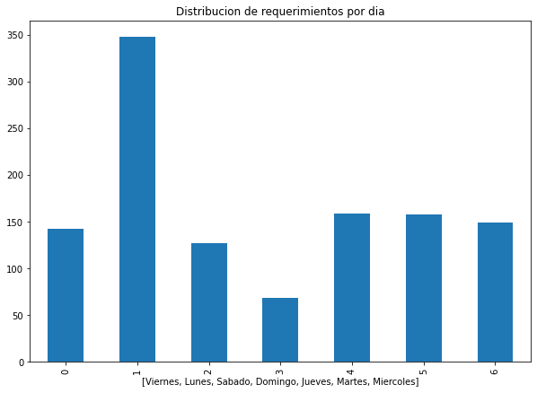

```python
tipos = ["Viernes","Lunes","Sabado", "Domingo", "Jueves", "Martes", "Miercoles"]
count= dfa['dia'].value_counts()
agrupamientoxdia.plot(kind='bar', xlabel=tipos, title='Distribucion de requerimientos por dia', figsize=(10,7));
```

## Tambien podemos visualizar esta distribucion de requerimientos por dia de manera porcentual.

### La distribucion porcentual de requerimientos por dia es la siguiente:

## Los dias con una mayor solicitud de requerimientos en los servicios de CamionGO se ven representados a continuacion:

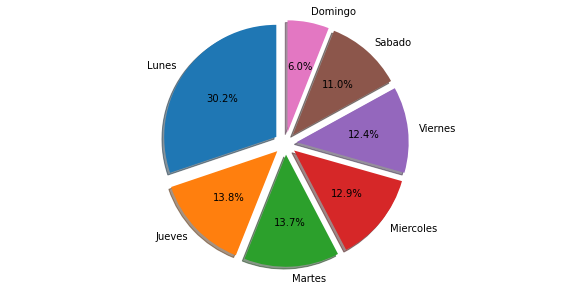

```python
tipos = ["Lunes", "Jueves", "Martes", "Miercoles", "Viernes", "Sabado", "Domingo"]
#tipos = dfa['dia'].unique()
total = dfa['dia'].value_counts().tolist()
desfase = (0.1, 0.1, 0.1, 0.1, 0.1, 0.1, 0.1)
plt.figure(figsize=(10,5))
plt.pie(total, labels=tipos, autopct='%1.1f%%', shadow=True, startangle=90, explode=desfase)
plt.axis("equal")
plt.show()
```

# Describiendo la distribucion de requerimientos por horario

## Analisis Estadistico de la caracteristica Hora

```python
print('Conteo:',dfa['hora'].count(),'Registros')
print('Promedio:',dfa['hora'].mean())
print('STD:',dfa['hora'].std())
print(dfa['hora'].quantile([.25, .5, .75]))
print('*******')
print('Mínimo:',min(dfa['hora']))
print('Máximo:',max(dfa['hora']))
```

```
Conteo: 1153 Registros
Promedio: 11.803989592367737
STD: 4.217162936857277
0.25     9
0.50    11
0.75    14
Name: hora, dtype: object
*******
Mínimo: 0
Máximo: 23
```

- Hay 1153 Registros en la columna
- El promedio corresponde a 11.80
- La desviación estándar es de 4.21, esto nos indica que la hora de mayores requerimientos de las observaciones varía dentro del intervalo [7.59, 16,01] [mean - std; mean + std] lo que quiere decir que en la gran mayoria de los requerimientos el horario oscila entre las 7 AM y 16 PM.
- Valor mínimo de la columna es 0, el cual corresponde a las 00 AM
- El 25% de las observaciones es menor a 9: Esto nos indica que el 25% de los Requerimientos de la muestra tomada se solicitan entre las 00 AM y 8 AM.
- El 50% de las observaciones es menor a 11: Esto nos indica que el 50% de los Requerimientos de la muestra tomada se solicitan se solicitan entre las 00 AM y 10 AM.
- El 75% de las observaciones es menor a 14: : Esto nos indica que el 75% de los Requerimientos de la muestra tomada se solicitan entre las 00 AM y 13 PM.
- El valor máximo de la columna es 23 es cual corresponde a las 23 PM

# Agrupando la cantidad de requerimientos por la caracteristica hora.

## Podemos observar que la distribucion horaria es la siguiente:

```python
groupingperhour = dfa.groupby('hora')['contador'].count()
grouping = pd.DataFrame(groupingperhour)
grouping = grouping.rename(columns={'contador':'requerimientos'})
grouping
```

| hora | requerimientos |
| --- | --- |
| 0 | 10 |
| 1 | 6 |
| 3 | 2 |
| 4 | 1 |
| 5 | 2 |
| 6 | 7 |
| 7 | 47 |
| 8 | 196 |
| 9 | 131 |
| 10 | 150 |
| 11 | 83 |
| 12 | 109 |
| 13 | 67 |
| 14 | 60 |
| 15 | 62 |
| 16 | 55 |
| 17 | 22 |
| 18 | 33 |
| 19 | 27 |
| 20 | 36 |
| 21 | 19 |
| 22 | 20 |
| 23 | 8 |

- Podemos ver como se distribuye la cantidad de requerimientos por horario en la muestra seleccionada.

## La representacion visual de la cantidad de requerimientos agrupadas por hora es la siguiente:

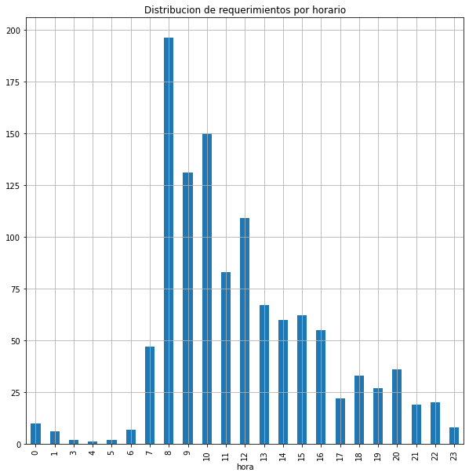

```python
plt.figure(figsize=(10,10))
groupingperhour.plot(kind='bar',grid=True, title='Distribucion de requerimientos por horario');
```

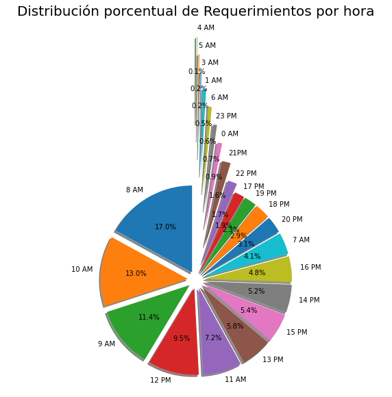

```python
tipos = ["8 AM", "10 AM", "9 AM", "12 PM", "11 AM", "13 PM", "15 PM", "14 PM", "16 PM", "7 AM", "20 PM", "18 PM", "19 PM", "17 PM", "22 PM", "21PM", "0 AM", "23 PM", "6 AM", "1 AM", "3 AM", "5 AM", "4 AM"]
#tipos = dfa['hora'].unique()
total = dfa['hora'].value_counts().tolist()
desfase = (0.1, 0.1, 0.1, 0.1, 0.1, 0.1, 0.1,0.1, 0.1, 0.1, 0.1, 0.1, 0.1, 0.1,0.2, 0.4, 0.6, 0.8, 1, 1.2, 1.4, 1.6, 1.8)
plt.figure(figsize=(10,10))
plt.pie(total, labels=tipos, autopct='%1.1f%%', shadow=True, startangle=90, explode=desfase)
plt.title('Distribución porcentual de Requerimientos por hora', fontsize=20)
plt.axis("equal")
plt.show()
```

# Describiendo la distribución de requerimientos por comuna

## Analisis estadistico inicial

```python
dfa['comuna'].describe()
```

```
count         1153
unique         139
top       Santiago
freq           124
Name: comuna, dtype: object
```

- Existen 1153 observaciones.
- Existen 139 comunas en la muestra de datos.
- La comuna con la mayor cantidad de requerimientos es Santiago.
- Su frecuencia de requerimientos para la comuna de Santiago es de 124.

## Agrupando la cantidad de requerimientos por la caracteristica comuna.

## Podemos observar que la distribucion de comunas es la siguiente:

```python
groupingpercommune = dfa.groupby('comuna')['contador'].count()
grouping = pd.DataFrame(groupingpercommune)
grouping = grouping.rename(columns={'contador':'requerimientos'})
grouping
```

| comuna | requerimientos |
| --- | --- |
| Algarrobo | 2 |
| Alto Hospicio | 4 |
| Alto del Carmen | 1 |
| Antofagasta | 55 |
| Arauco | 1 |
| ... | ... |
| Villarrica | 8 |
| Vitacura | 7 |
| Viña del Mar | 21 |
| Ñiquén | 1 |
| Ñuñoa | 18 |

139 rows × 1 columns

## La representacion visual de la cantidad de requerimientos agrupadas por comuna es la siguiente:

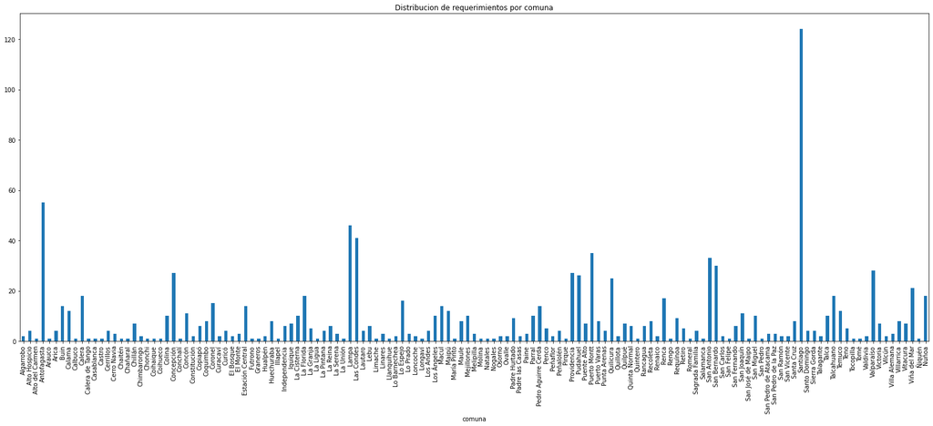

```python
plt.figure(figsize=(27,10))
groupingpercommune.plot(kind='bar', title='Distribucion de requerimientos por comuna');
```

## Para este analisis estadistico de tipo descriptivo seleccionaremos las 5 comunas con una mayor cantidad de requerimientos.

## Distribucion requerimientos a nivel de comunas es la siguiente:

| N° | Comunas |
| --- | --- |
| 1 | Santiago |
| 2 | Antofagasta |
| 3 | Lampa |
| 4 | Las Condes |
| 5 | Puerto Montt |

### esta tabla nos servira para describir el comportamiento de los requerimientos por horario en las comunas seleccionadas.

# Describiendo la distribucion de requerimientos por region

```python
print('Conteo:',dfa['region'].count(),'Registros')
print('Promedio:',dfa['region'].mean())
print('STD:',dfa['region'].std())
print(dfa['region'].quantile([.25, .5, .75]))
print('*******')
print('Mínimo:',min(dfa['region']))
print('Máximo:',max(dfa['region']))
```

```
Conteo: 1153 Registros
Promedio: 9.761491760624457
STD: 3.9371594026159773
0.25     6
0.50    13
0.75    13
Name: region, dtype: object
*******
Mínimo: 1
Máximo: 16
```

1. Hay 1153 Registros en la columna.
2. El promedio corresponde a 9.76.
3. La desviación estándar es de 3.93, esto nos indica que las regiones de mayores requerimientos de las observaciones varía dentro del intervalo [5.82, 13,69] [mean - std; mean + std] lo que quiere decir que en la gran mayoria de los requerimientos la region oscila entre la quinta y decimotercera region.
4. Valor mínimo de la columna es 1, el cual corresponde a la primera region de Tarapacá.
5. El 25% de las observaciones son menor a 6: Esto nos indica que el 25% de los Requerimientos de la muestra tomada se solicitan entre la Region de Tarapacá y la region de Ohiggins.
6. El 50% de las observaciones son menor a 13: Esto nos indica que el 50% de los Requerimientos de la muestra tomada se solicitan entre la Region de Tarapacá y la region region metropolitana.
7. El 75% de las observaciones es menor a 13: : Esto nos indica que el 75% de los Requerimientos de la muestra tomada se solicitan entre la Region de Tarapacá y la region region metropolitana.
8. El valor máximo de la columna es 16 es cual corresponde a la region de Ñuble.

## Agrupando la cantidad de requerimientos por la caracteristica region.

### Podemos observar que la distribucion de requerimientos es la siguiente:

```python
groupingperregion = dfa.groupby('region')['contador'].count()
grouping = pd.DataFrame(groupingperregion)
grouping = grouping.rename(columns={'contador':'requerimientos'})
grouping
```

| region | requerimientos |
| --- | --- |
| 1 | 11 |
| 2 | 85 |
| 3 | 7 |
| 4 | 16 |
| 5 | 139 |
| 6 | 35 |
| 7 | 54 |
| 8 | 96 |
| 9 | 39 |
| 10 | 50 |
| 11 | 1 |
| 12 | 5 |
| 13 | 604 |
| 14 | 4 |
| 15 | 4 |
| 16 | 3 |

- Podemos ver como se distribuye la cantidad de requerimientos por region en la muestra seleccionada.

## La representacion visual y porcentual de la cantidad de requerimientos agrupadas por region es la siguiente:

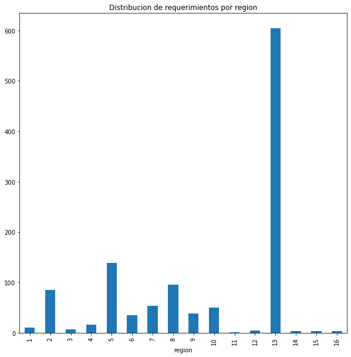

```python
groupingperregion.plot(kind='bar', title='Distribucion de requerimientos por region', figsize=(10,10));
```

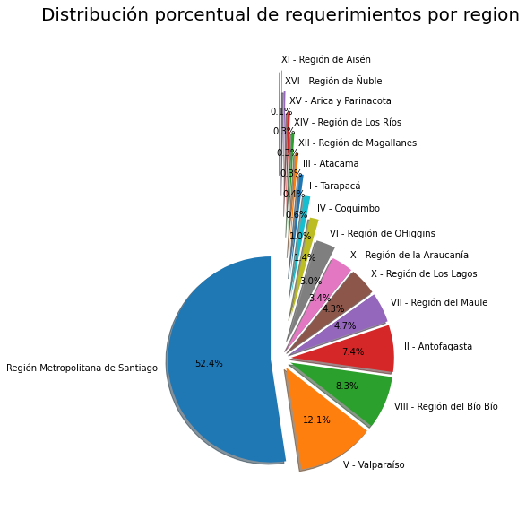

```python
tipos = ["Región Metropolitana de Santiago", "V - Valparaíso", "VIII - Región del Bío Bío", "II - Antofagasta", "VII - Región del Maule", "X - Región de Los Lagos", "IX - Región de la Araucanía", "VI - Región de OHiggins", "IV - Coquimbo", "I - Tarapacá", "III - Atacama", "XII - Región de Magallanes", "XIV - Región de Los Ríos", "XV - Arica y Parinacota", "XVI - Región de Ñuble","XI - Región de Aisén"]
#tipos = dfa['region'].unique()
total = dfa['region'].value_counts().tolist()
desfase = (0.1, 0.1, 0.1, 0.1, 0.1, 0.1, 0.1,0.2, 0.4, 0.6, 0.8, 1, 1.2, 1.4, 1.6, 1.8)
plt.figure(figsize=(5,10))
plt.pie(total, labels=tipos, autopct='%1.1f%%', shadow=True, startangle=90, explode=desfase)
plt.title('Distribución porcentual de requerimientos por region', fontsize=20)
plt.axis("equal")
plt.show()
```

# Vamos a seleccionar las regiones con una mayor distribucion porcentual de requerimientos para desarrollar este analisis

| N° | region |
| --- | --- |
| 2 | II - Antofagasta |
| 5 | V - Valparaíso |
| 7 | VII - Región del Maule |
| 8 | VIII - Región del Bío Bío |
| 13 | Región Metropolitana de Santiago |

# Distribucion diaria de requerimientos en regiones seleccionadas.

## Distribucion Diaria de requerimientos en La Region Metropolitana

```python
groupingpersantiago = dfa[dfa['region']== 13]['contador'].value_counts()
grouping = pd.DataFrame(groupingpersantiago)
grouping = grouping.rename(columns={'contador':'requerimientos'})
grouping
```

|  | requerimientos |
| --- | --- |
| 1 | 604 |

- 604 requerimientos de la muestra son solicitados desde la region metropolitana

```python
groupingpersantiago = dfa[dfa['region']== 13]['dia'].value_counts()
grouping = pd.DataFrame(groupingpersantiago)
grouping = grouping.rename(columns={'dia':'requerimientos'})
grouping
```

|  | requerimientos |
| --- | --- |
| 1 | 147 |
| 5 | 99 |
| 6 | 90 |
| 4 | 84 |
| 0 | 81 |
| 2 | 68 |
| 3 | 35 |

- Podemos ver como se distribuye la cantidad de requerimientos diarios en la region metropolitana

## La representacion visual y porcentual de la cantidad de requerimientos agrupados por dia en la region de metropolitana es la siguiente:

```
 [Text(-0.8306919141473897, 0.8659970806937781, 'Lunes'),
 [Text(-0.48457028325264395, 0.5051649637380372, '24.3%'),
```

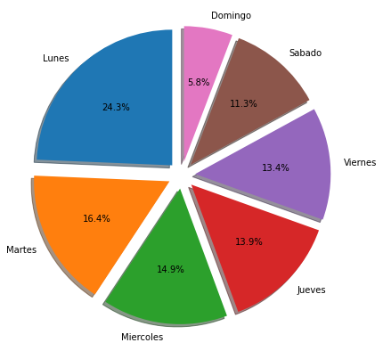

```python
plt.figure(figsize=(10,7))
tipos = ["Lunes", "Martes", "Miercoles", "Jueves", "Viernes", "Sabado", "Domingo"]
desfase = (0.1, 0.1, 0.1,0.1, 0.1, 0.1, 0.1)
grafico = dfa[dfa['region']== 13]['dia'].value_counts()
plt.pie(grafico ,autopct='%1.1f%%', shadow=True, startangle=90, labels = tipos, explode=desfase)
```

### Analisis de la muestra en la region metropolitana

- El lunes es el dia con mayor frecuencia de requerimientos en la region metropolitana.
- La distribucion porcentual nos muestra que entre el martes y viernes se distribuyen de manera muy similiar la frecuencia de requerimientos en la region metropolitana.
- El dia sabado es un dia que tiene una considerable frecuencia de requerimientos en la region metropolitana. Podriamos decir que la muestra nos indica que la gran parte de requerimientos en la region metropolitana se distribuyen entre los dias lunes a sabado.
- El dia domingo de la muestra se queda con la menor cantidad de requerimientos. Esto nos indica una baja de requerimientos para ese dia, pero tambien podemos inferir que existe una menor cantidad de requerimientos que si solicita para ese dia. Por lo tanto es un dia que a pesar de su baja frecuencia se debe considerar.

## Distribucion Diaria de requerimientos en la region de valparaiso

```python
groupingpervalparaiso = dfa[dfa['region']== 5]['contador'].value_counts()
grouping = pd.DataFrame(groupingpervalparaiso)
grouping = grouping.rename(columns={'contador':'requerimientos'})
grouping
```

|  | requerimientos |
| --- | --- |
| 1 | 139 |

- 139 requerimientos de la muestra son solicitados desde la region de valparaiso

```python
groupingpervalparaiso = dfa[dfa['region']== 5]['dia'].value_counts()
grouping = pd.DataFrame(groupingpervalparaiso)
grouping = grouping.rename(columns={'dia':'requerimientos'})
grouping
```

|  | requerimientos |
| --- | --- |
| 1 | 53 |
| 5 | 24 |
| 4 | 21 |
| 6 | 15 |
| 2 | 12 |
| 0 | 9 |
| 3 | 5 |

- Podemos ver como se distribuye la cantidad de requerimientos diarios en la region de valparaiso

## La representacion visual y porcentual de la cantidad de requerimientos agrupados por dia en la region de valparaiso es la siguiente:

```
 [Text(-1.117519694455796, 0.4372067388586598, 'Lunes'),
 [Text(-0.6518864884325476, 0.2550372643342182, '38.1%'),
```

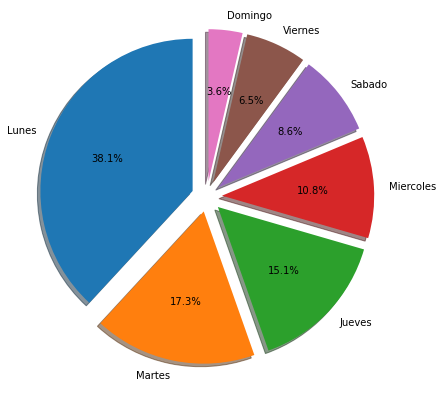

```python
plt.figure(figsize=(10,7))
tipos = ["Lunes", "Martes", "Jueves", "Miercoles","Sabado", "Viernes", "Domingo"]
desfase = (0.1, 0.1, 0.1,0.1, 0.1, 0.1, 0.1)
grafico = dfa[dfa['region']== 5]['dia'].value_counts()
plt.pie(grafico ,autopct='%1.1f%%', shadow=True, startangle=90, labels = tipos, explode=desfase)
```

### Analisis de la muestra en la region de valparaiso

- El lunes es el dia con mayor frecuencia de requerimientos en la region de valparaiso.
- La distribucion porcentual nos muestra que el martes y jueves se distribuyen de manera muy similiar la frecuencia de requerimientos en la region de valparaiso.
- Los dias viernes, sabados y domingos de la muestra se quedan con la menor cantidad de requerimientos. Esto nos indica una baja de requerimientos para esos dias, pero tambien podemos inferir que existe una menor cantidad de requerimientos que si solicita para aquellos dias. Por lo tanto estos dias a pesar de su baja frecuencia se deben considerar.

## Distribucion Diaria de requerimientos en la region del Bío Bío

```python
groupingperbiobio = dfa[dfa['region']== 8]['contador'].value_counts()
grouping = pd.DataFrame(groupingperbiobio)
grouping = grouping.rename(columns={'contador':'requerimientos'})
grouping
```

|  | requerimientos |
| --- | --- |
| 1 | 96 |

- 96 requerimientos de la muestra son solicitados desde la region del bio bio

```python
groupingperbiobio = dfa[dfa['region']== 8]['dia'].value_counts()
grouping = pd.DataFrame(groupingperbiobio)
grouping = grouping.rename(columns={'dia':'requerimientos'})
grouping
```

|  | requerimientos |
| --- | --- |
| 1 | 38 |
| 4 | 14 |
| 6 | 13 |
| 5 | 11 |
| 0 | 9 |
| 2 | 7 |
| 3 | 4 |

- Podemos ver como se distribuye la cantidad de requerimientos diarios en la region del bio bio

## La representacion visual y porcentual de la cantidad de requerimientos agrupados por dia en la region del bio bio es la siguiente:

```
 [Text(-1.1363161674322602, 0.3857273229005951, 'Lunes'),
 [Text(-0.6628510976688184, 0.2250076050253471, '39.6%'),
```

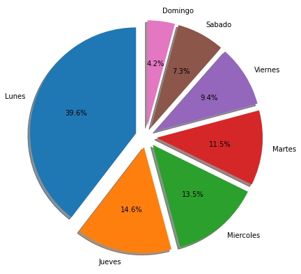

```python
plt.figure(figsize=(10,7))
tipos = ["Lunes", "Jueves","Miercoles", "Martes","Viernes","Sabado",  "Domingo"]
desfase = (0.1, 0.1, 0.1,0.1, 0.1, 0.1, 0.1)
grafico = dfa[dfa['region']== 8]['dia'].value_counts()
plt.pie(grafico ,autopct='%1.1f%%', shadow=True, startangle=90, labels = tipos, explode=desfase)
```

### Analisis de la muestra en la region del bio bio

- El lunes es el dia con mayor frecuencia de requerimientos en la region del bio bio.
- La distribucion porcentual nos muestra que entre el dia martes y jueves se distribuyen de manera muy similiar la frecuencia de requerimientos en la region del bio bio.
- Los dias viernes, sabados y domingos de la muestra se quedan con la menor cantidad de requerimientos. Esto nos indica una baja de requerimientos para el fin de semana, pero tambien podemos inferir que existe una menor cantidad de requerimientos que si solicita para aquellos dias. Por lo tanto estos dias a pesar de su baja frecuencia se deben considerar.

## Distribucion Diaria de requerimientos en la region de antofagasta

```python
groupingperantofagasta = dfa[dfa['region']== 2]['contador'].value_counts()
grouping = pd.DataFrame(groupingperantofagasta)
grouping = grouping.rename(columns={'contador':'requerimientos'})
grouping
```

|  | requerimientos |
| --- | --- |
| 1 | 85 |

- 85 requerimientos de la muestra son solicitados desde la region de antofagasta

```python
groupingperantofagasta = dfa[dfa['region']== 2]['dia'].value_counts()
grouping = pd.DataFrame(groupingperantofagasta)
grouping = grouping.rename(columns={'dia':'requerimientos'})
grouping
```

|  | requerimientos |
| --- | --- |
| 1 | 49 |
| 2 | 12 |
| 4 | 8 |
| 6 | 5 |
| 0 | 5 |
| 5 | 3 |
| 3 | 3 |

- Podemos ver como se distribuye la cantidad de requerimientos diarios en la region de antofagasta

## La representacion visual y porcentual de la cantidad de requerimientos agrupados por dia en la region de antofagasta es la siguiente:

```
 [Text(-1.1655372156553157, -0.2855223264868353, 'Lunes'),
 [Text(-0.6798967091322673, -0.1665546904506539, '57.6%'),
```

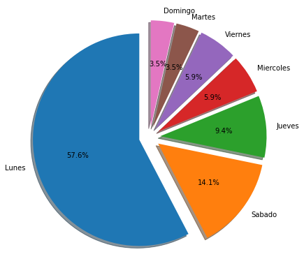

```python
plt.figure(figsize=(10,7))
tipos = ["Lunes","Sabado", "Jueves","Miercoles","Viernes", "Martes", "Domingo"]
desfase = (0.1, 0.1, 0.1,0.1, 0.1, 0.1, 0.1)
grafico = dfa[dfa['region']== 2]['dia'].value_counts()
plt.pie(grafico ,autopct='%1.1f%%', shadow=True, startangle=90, labels = tipos, explode=desfase)
```

### Analisis de la muestra en la region de antofagasta

- El lunes es el dia con una frecuencia considerable de requerimientos en la region de antofagasta. Un dia de alta demanda de requerimientos para esta region.
- El dia sabado a pesar de ser un dia de "fin de semana" para muchos rubros sigue siendo un dia laboral y esto queda representado al ser el segundo dia con el mayor porcentaje de requerimientos en esta region.
- La distribucion porcentual nos muestra que los dias miercoles y viernes, martes y domingos, se distribuyen de manera similiar la frecuencia de requerimientos en la region de antofagasta.

## Distribucion Diaria de requerimientos en la region del maule

```python
groupingpermaule = dfa[dfa['region']== 7]['contador'].value_counts()
grouping = pd.DataFrame(groupingpermaule)
grouping = grouping.rename(columns={'contador':'requerimientos'})
grouping
```

|  | requerimientos |
| --- | --- |
| 1 | 54 |

- 54 requerimientos de la muestra son solicitados desde la region del maule

```python
groupingpermaule = dfa[dfa['region']== 7]['dia'].value_counts()
grouping = pd.DataFrame(groupingpermaule)
grouping = grouping.rename(columns={'dia':'requerimientos'})
grouping
```

|  | requerimientos |
| --- | --- |
| 1 | 17 |
| 4 | 9 |
| 0 | 8 |
| 6 | 6 |
| 5 | 5 |
| 2 | 5 |
| 3 | 4 |

- Podemos ver como se distribuye la cantidad de requerimientos diarios en la region del maule

## La representacion visual y porcentual de la cantidad de requerimientos agrupados por dia en la region del maule es la siguiente:

```
 [Text(-1.0025853554026367, 0.65941080149795, 'Lunes'),
 [Text(-0.5848414573182046, 0.38465630087380415, '31.5%'),
```

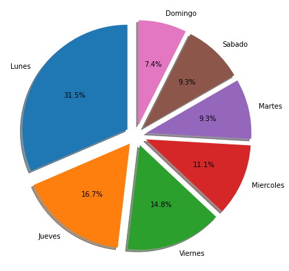

```python
plt.figure(figsize=(10,7))
tipos = ["Lunes","Jueves","Viernes","Miercoles","Martes", "Sabado", "Domingo"]
desfase = (0.1, 0.1, 0.1,0.1, 0.1, 0.1, 0.1)
grafico = dfa[dfa['region']== 7]['dia'].value_counts()
plt.pie(grafico ,autopct='%1.1f%%', shadow=True, startangle=90, labels = tipos, explode=desfase)
```

## Conclusion de la distribucion diaria de requerimientos en las regiones seleccionadas:

A nivel regional la descripcion de esta caracteristica nos muestra que se generan requerimientos durante toda la semana, lunes a domingo.

De lunes a sabado se generan la mayor cantidad de requerimientos en la muestra seleccionada.

La tendencia diaria de requerimientos se la lleva el dia lunes. Podriamos inferir que es el dia de mayor demanda.

Se podria aumentar el nivel de detalle y describir la distrubucion diaria de requerimientos pero por comuna. Esto lo realizaremos mas adelante.

# Distribucion porcentual de requerimientos por comunas en las regiones seleccionadas para el analisis

## Vamos a describir las comunas con la mayor cantidad de requerimientos por region.

## Region de antofagasta

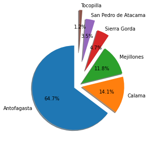

```python
grafico = dfa[dfa['region']==2]['comuna'].value_counts()
desfase = (0.1, 0.1,0.1, 0.4,0.6, 0.8)
plt.pie(grafico, autopct='%1.1f%%', shadow=True, startangle=90, labels = grafico.index, explode=desfase)
plt.figure(figsize=(10,5))
```

- La comuna seleccionada es Antofagasta. Comuna que representa la mayor frecuencia de requerimientos de la region.

## Region metropolitana

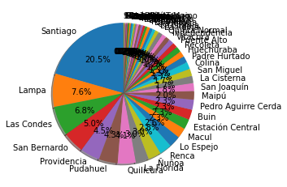

```python
grafico = dfa[dfa['region']==13]['comuna'].value_counts()
#desfase = (0.1, 0.1,0.1, 0.4,0.6, 0.8)
plt.pie(grafico, autopct='%1.1f%%', shadow=True, startangle=90, labels = grafico.index)
plt.figure(figsize=(15,15))
```

- Al ser tantas las comunas de la region metropolitana que tienen registro de requerimientos. Al momento de representarlas en una grafica tenemos el problema que no se logran apreciar a simple vista los porcentajes y comunas con baja frecuencia.
- La comuna seleccionada para la descripcion es Santiago, comuna que representa la mayor cantidad de requerimientos para esta region.

## Region de valparaiso

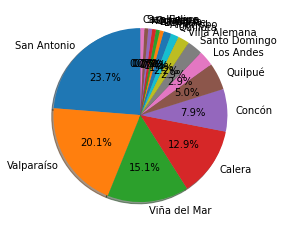

```python
grafico = dfa[dfa['region']==5]['comuna'].value_counts()
#desfase = (0.1, 0.1,0.1, 0.4,0.6, 0.8)
plt.pie(grafico, autopct='%1.1f%%', shadow=True, startangle=90, labels = grafico.index)
plt.figure(figsize=(10,10))
```

- Al ser tantas las comunas de la region de valparaiso que tienen registro de requerimientos. Al momento de representarlas en una grafica tenemos el problema que no se logran apreciar a simple vista los porcentajes y comunas con baja frecuencia.
- La comuna seleccionada para la descripcion es San Antonio, comuna que representa la mayor cantidad de requerimientos para esta region.

## Region del Bio Bio

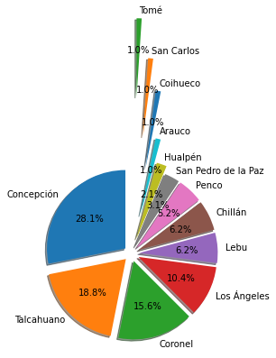

```python
grafico = dfa[dfa['region']==8]['comuna'].value_counts()
desfase = (0.1, 0.1,0.1,0.1, 0.1,0.1,0.1, 0.1,0.2,0.5, 1.1,1.5, 2)
plt.pie(grafico, autopct='%1.1f%%', shadow=True, startangle=90, labels = grafico.index, explode=desfase)
plt.figure(figsize=(10,10))
```

- La comuna seleccionada para la descripcion es Concepción, comuna que representa la mayor cantidad de requerimientos para esta region.

## Region del maule

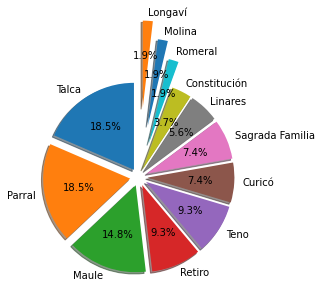

```python
grafico = dfa[dfa['region']==7]['comuna'].value_counts()
desfase = (0.1, 0.1,0.1,0.1, 0.1,0.1,0.1, 0.1,0.1, 0.4,0.6, 0.8)
plt.pie(grafico, autopct='%1.1f%%', shadow=True, startangle=90, labels = grafico.index, explode=desfase)
plt.figure(figsize=(10,10))
```

- La comuna seleccionada para la descripcion es Talca, comuna que representa la mayor cantidad de requerimientos junto a parral para esta region.

# Distribucion diaria de requerimientos en las comunas seleccionadas para el analisis.

| N° | Comunas |
| --- | --- |
| 1 | Santiago |
| 2 | Antofagasta |
| 3 | San Antonio |
| 4 | Concepción |
| 5 | Talca |

## Distribucion Diaria de requerimientos en la comuna de santiago

```python
groupingperstgo = dfa[dfa['comuna']== 'Santiago']['contador'].value_counts()
grouping = pd.DataFrame(groupingperstgo)
grouping = grouping.rename(columns={'contador':'requerimientos'})
grouping
```

|  | requerimientos |
| --- | --- |
| 1 | 124 |

- 124 requerimientos de la muestra son solicitados desde la comuna santiago.

```python
groupingperstgo = dfa[dfa['comuna']== 'Santiago']['dia'].value_counts()
grouping = pd.DataFrame(groupingperstgo)
grouping = grouping.rename(columns={'dia':'requerimientos'})
grouping
```

|  | requerimientos |
| --- | --- |
| 1 | 56 |
| 6 | 23 |
| 5 | 15 |
| 4 | 11 |
| 2 | 9 |
| 0 | 7 |
| 3 | 3 |

- Podemos ver como se distribuye la cantidad de requerimientos diarios en la comuna de santiago.

## La representacion visual y porcentual de la cantidad de requerimientos agrupados por dia en la comuna de santiago es la siguiente:

```
 [Text(-1.1861619815103384, 0.18171338316004043, 'Lunes'),
 [Text(-0.6919278225476974, 0.10599947351002358, '45.2%'),
```

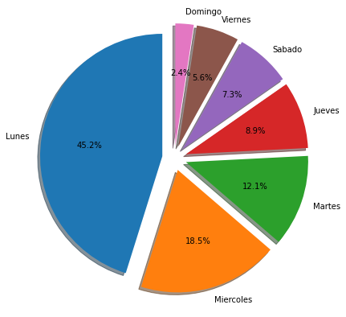

```python
plt.figure(figsize=(10,7))
tipos = ["Lunes","Miercoles","Martes","Jueves","Sabado","Viernes","Domingo"]
desfase = (0.1, 0.1, 0.1,0.1, 0.1, 0.1, 0.1)
grafico = dfa[dfa['comuna']== 'Santiago']['dia'].value_counts()
plt.pie(grafico ,autopct='%1.1f%%', shadow=True, startangle=90, labels = tipos, explode=desfase)
```

### Analisis de la muestra en la comuna de santiago

- El lunes es el dia con la mayor frecuencia de requerimientos en la comuna de santiago. el dia de mayor demanda de requerimientos para esta comuna.
- La distribucion nos muestra que la gran mayoria de los requerimientos en la comuna de santiago se distribuyen entre el lunes y jueves.
- Los dias viernes y sabado muestran una menor frecuencia de requerimientos en esta comuna, aun asi se tiene una frecuencia a considerar. Esto debido a que muchos rubros trabajan hasta el dia sabado.
- El domingo es el dia con la menor frecuencia de requerimientos para esta comuna.
- La comuna de santiago nos muestra que durante toda la semana existe una necesidad de requerimientos.

## Distribucion diaria de requerimientos en la comuna de antofagasta

```python
groupingperantofagasta = dfa[dfa['comuna']== 'Antofagasta']['contador'].value_counts()
grouping = pd.DataFrame(groupingperantofagasta)
grouping = grouping.rename(columns={'contador':'requerimientos'})
grouping
```

|  | requerimientos |
| --- | --- |
| 1 | 55 |

- 55 requerimientos de la muestra son solicitados desde la comuna de antofagasta.

```python
groupingperantofagasta = dfa[dfa['comuna']== 'Antofagasta']['dia'].value_counts()
grouping = pd.DataFrame(groupingperantofagasta)
grouping = grouping.rename(columns={'dia':'requerimientos'})
grouping
```

|  | requerimientos |
| --- | --- |
| 1 | 30 |
| 2 | 8 |
| 4 | 7 |
| 0 | 5 |
| 5 | 3 |
| 6 | 1 |
| 3 | 1 |

- Podemos ver como se distribuye la cantidad de requerimientos diarios en la comuna de antofagasta.

## La representacion visual y porcentual de la cantidad de requerimientos agrupados por dia en la comuna de antofagasta es la siguiente:

```
 [Text(-1.187785721535642, -0.170777866587138, 'Lunes'),
 [Text(-0.6928750042291245, -0.0996204221758305, '54.5%'),
```

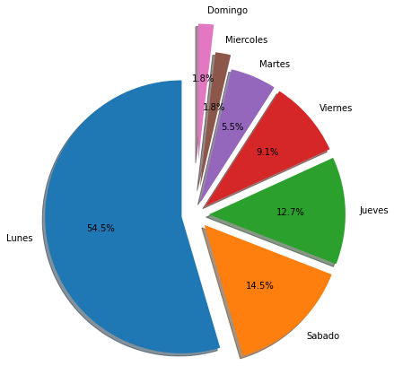

```python
plt.figure(figsize=(10,7))
tipos = ["Lunes","Sabado","Jueves","Viernes","Martes","Miercoles","Domingo"]
desfase = (0.1, 0.1, 0.1,0.1, 0.1, 0.2, 0.4)
grafico = dfa[dfa['comuna']== 'Antofagasta']['dia'].value_counts()
plt.pie(grafico ,autopct='%1.1f%%', shadow=True, startangle=90, labels = tipos, explode=desfase)
```

## Distribucion diaria de requerimientos en la comuna de San Antonio

```python
groupingpersanantonio = dfa[dfa['comuna']== 'San Antonio']['contador'].value_counts()
grouping = pd.DataFrame(groupingpersanantonio)
grouping = grouping.rename(columns={'contador':'requerimientos'})
grouping
```

|  | requerimientos |
| --- | --- |
| 1 | 33 |

- 33 requerimientos de la muestra son solicitados desde la comuna de San Antonio.

```python
groupingpersanantonio = dfa[dfa['comuna']== 'San Antonio']['dia'].value_counts()
grouping = pd.DataFrame(groupingpersanantonio)
grouping = grouping.rename(columns={'dia':'requerimientos'})
grouping
```

|  | requerimientos |
| --- | --- |
| 1 | 17 |
| 5 | 6 |
| 6 | 5 |
| 4 | 3 |
| 0 | 2 |

- Podemos ver como se distribuye la cantidad de requerimientos diarios en la comuna de San Antonio.

## La representacion visual y porcentual de la cantidad de requerimientos agrupados por dia en la comuna de San Antonio es la siguiente:

```
 [Text(-1.1986408096115737, -0.05709824457644138, 'Lunes'),
 [Text(-0.6992071389400847, -0.03330730933625747, '51.5%'),
```

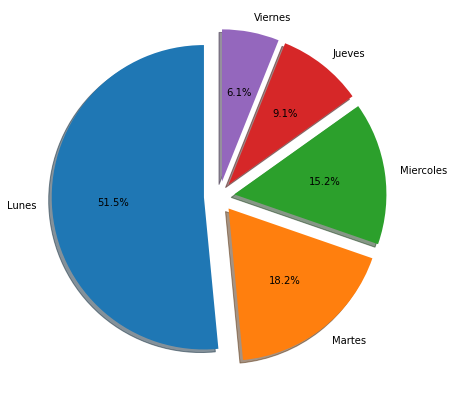

```python
plt.figure(figsize=(10,7))
tipos = ["Lunes","Martes","Miercoles","Jueves","Viernes"]
desfase = (0.1, 0.1, 0.1,0.1, 0.1)
grafico = dfa[dfa['comuna']== 'San Antonio']['dia'].value_counts()
plt.pie(grafico ,autopct='%1.1f%%', shadow=True, startangle=90, labels = tipos, explode=desfase)
```

## Distribucion diaria de requerimientos en la comuna de Concepción

```python
groupingperconcepcion = dfa[dfa['comuna']== 'Concepción']['contador'].value_counts()
grouping = pd.DataFrame(groupingperconcepcion)
grouping = grouping.rename(columns={'contador':'requerimientos'})
grouping
```

|  | requerimientos |
| --- | --- |
| 1 | 27 |

- 27 requerimientos de la muestra son solicitados desde la comuna de Concepcion.

```python
groupingperconcepcion = dfa[dfa['comuna']== 'Concepción']['dia'].value_counts()
grouping = pd.DataFrame(groupingperconcepcion)
grouping = grouping.rename(columns={'dia':'requerimientos'})
grouping
```

|  | requerimientos |
| --- | --- |
| 1 | 15 |
| 4 | 4 |
| 0 | 4 |
| 2 | 2 |
| 6 | 1 |
| 3 | 1 |

- Podemos ver como se distribuye la cantidad de requerimientos diarios en la comuna de concepcion.

## La representacion visual y porcentual de la cantidad de requerimientos agrupados por dia en la comuna de Concepción es la siguiente:

```
 [Text(-1.1817692862726557, -0.20837791155162894, 'Lunes'),
 [Text(-0.6893654169923824, -0.1215537817384502, '55.6%'),
```

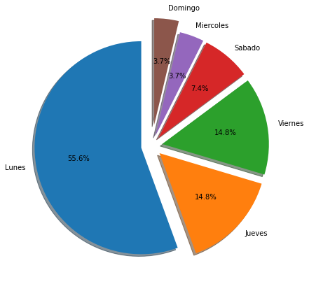

```python
plt.figure(figsize=(10,7))
tipos = ["Lunes","Jueves","Viernes", "Sabado","Miercoles", "Domingo"]
desfase = (0.1, 0.1, 0.1,0.1, 0.1, 0.2)
grafico = dfa[dfa['comuna']== 'Concepción']['dia'].value_counts()
plt.pie(grafico ,autopct='%1.1f%%', shadow=True, startangle=90, labels = tipos, explode=desfase)
```

## Distribucion diaria de requerimientos en la comuna de Talca

```python
groupingpertalca = dfa[dfa['comuna']== 'Talca']['contador'].value_counts()
grouping = pd.DataFrame(groupingpertalca)
grouping = grouping.rename(columns={'contador':'requerimientos'})
grouping
```

|  | requerimientos |
| --- | --- |
| 1 | 10 |

- 10 requerimientos de la muestra son solicitados desde la comuna de Talca.
- Importante destacar que estamos describiendo las comunas con mayor cantidad de requerimientos de las regiones seleccionadas.

```python
groupingpertalca = dfa[dfa['comuna']== 'Talca']['dia'].value_counts()
grouping = pd.DataFrame(groupingpertalca)
grouping = grouping.rename(columns={'dia':'requerimientos'})
grouping
```

|  | requerimientos |
| --- | --- |
| 5 | 4 |
| 6 | 2 |
| 3 | 1 |
| 2 | 1 |
| 1 | 1 |
| 0 | 1 |

- Podemos ver como se distribuye la cantidad de requerimientos diarios en la comuna de Talca.

## La representacion visual y porcentual de la cantidad de requerimientos agrupados por dia en la comuna de Talca es la siguiente:

```
 [Text(-1.1412678264979264, 0.3708203718792959, 'Martes'),
  Text(5.6176054520849516e-08, -1.1999999999999986, 'Miercoles'),
  Text(1.199999999999997, 8.426408128510657e-08, 'Sabado'),
 [Text(-0.6657395654571236, 0.21631188359625594, '40.0%'),
  Text(3.276936513716222e-08, -0.6999999999999992, '20.0%'),
  Text(0.6999999999999983, 4.9154047416312164e-08, '10.0%'),
```

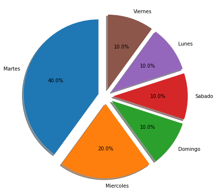

```python
plt.figure(figsize=(10,7))
tipos = ["Martes","Miercoles","Domingo","Sabado","Lunes", "Viernes"]
desfase = (0.1, 0.1, 0.1,0.1, 0.1,0.1)
grafico = dfa[dfa['comuna']== 'Talca']['dia'].value_counts()
plt.pie(grafico ,autopct='%1.1f%%', shadow=True, startangle=90, labels = tipos, explode=desfase)
```

## Conclusion de la distribucion diaria de requerimientos en las comunas seleccionadas:

Las comunas seleccionadas nos describen una baja cantidad de requerimientos en comparacion del total de registros seleccionados.

De lunes a sabado se generan la mayor cantidad de requerimientos en la muestra seleccionada.

La tendencia diaria de requerimientos se la lleva el dia lunes. Podriamos inferir que es el dia de mayor demanda.

En ciertas comunas de la muestra seleccionada, existen dias que no registran requerimientos. Esto debido a la baja frecuencia al momento de agruparlo por comunas.

# Descripcion horaria de requerimientos en regiones y comunas seleccionadas para el analisis.

## Iniciaremos con la distribucion horaria de requerimientos en las regiones seleccionadas.

## Podemos observar que la distribucion horaria de requerimientos en la region metropolitana es la siguiente:

```python
groupingpersantiago = dfa[dfa['region']== 13]['contador'].value_counts()
grouping = pd.DataFrame(groupingpersantiago)
grouping = grouping.rename(columns={'contador':'requerimientos'})
grouping
```

|  | requerimientos |
| --- | --- |
| 1 | 604 |

- 604 requerimientos de la muestra son solicitados desde la region metropolitana.

```python
groupingpersantiago = dfa[dfa['region']== 13]['hora'].value_counts()
grouping = pd.DataFrame(groupingpersantiago)
grouping = grouping.rename(columns={'hora':'requerimientos'})
grouping
```

|  | requerimientos |
| --- | --- |
| 10 | 84 |
| 9 | 73 |
| 12 | 62 |
| 11 | 61 |
| 8 | 53 |
| 15 | 41 |
| 14 | 38 |
| 13 | 36 |
| 16 | 35 |
| 7 | 23 |
| 19 | 19 |
| 20 | 16 |
| 21 | 14 |
| 18 | 14 |
| 17 | 11 |
| 22 | 8 |
| 0 | 4 |
| 6 | 3 |
| 1 | 3 |
| 5 | 2 |
| 23 | 2 |
| 4 | 1 |
| 3 | 1 |

- Podemos ver como se distribuye el horario de requerimientos en la region metropolitana.

## La representacion visual y porcentual de la cantidad de requerimientos agrupados por horario en la region metropolitana es la siguiente:

```
 [Text(-0.5077703704469932, 1.0872760693108827, '10'),
 [Text(-0.296199382760746, 0.6342443737646815, '13.9%'),
```

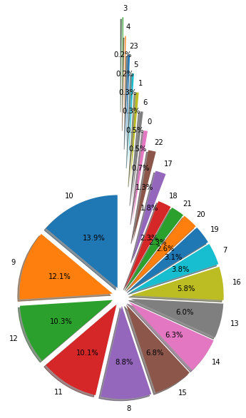

```python
desfase = (0.1,0.1, 0.1,0.1, 0.1,0.1, 0.1,0.1, 0.1,0.1, 0.1,0.1, 0.1,0.1, 0.4, 0.6, 0.8, 1, 1.2, 1.4, 1.6, 1.8, 2)
grafico = dfa[dfa['region']== 13]['hora'].value_counts()
plt.figure(figsize=(7,6))
plt.pie(grafico, autopct='%1.1f%%', shadow=True, startangle=90, labels = grafico.index, explode=desfase)
```

### Analisis de la muestra en la region metropolitana

- En la region metropolitana el horario con una mayor cantidad de requerimientos es a las 10 AM.
- Por lo tanto de la muestra podriamos inferir que entre las 09 AM y 10 AM seria el horario de mayor demanda en la region.
- Entre las 08 AM y 16 PM es el horario con mayor frecuencia de requerimientos en esta region.
- Entre las 10 PM y 06 AM es el rango horario con menor frecuencia de requerimientos en esta region.

## Podemos observar que la distribucion horaria de requerimientos en la region de Antofagasta es la siguiente:

```python
groupingperantofagasta = dfa[dfa['region']== 2]['contador'].value_counts()
grouping = pd.DataFrame(groupingperantofagasta)
grouping = grouping.rename(columns={'contador':'requerimientos'})
grouping
```

|  | requerimientos |
| --- | --- |
| 1 | 85 |

- 85 requerimientos de la muestra son solicitados desde la region de antofagasta.

```python
groupingperantofagasta = dfa[dfa['region']== 2]['hora'].value_counts()
grouping = pd.DataFrame(groupingperantofagasta)
grouping = grouping.rename(columns={'hora':'requerimientos'})
grouping
```

|  | requerimientos |
| --- | --- |
| 8 | 30 |
| 9 | 18 |
| 10 | 10 |
| 11 | 6 |
| 12 | 5 |
| 17 | 3 |
| 18 | 2 |
| 16 | 2 |
| 15 | 2 |
| 0 | 2 |
| 22 | 1 |
| 20 | 1 |
| 19 | 1 |
| 13 | 1 |
| 6 | 1 |

- Podemos ver como se distribuye el horario de requerimientos en la region de antofagasta.

## La representacion visual y porcentual de la cantidad de requerimientos agrupados por horario en la region de antofagasta es la siguiente:

```
 [Text(-1.0741959643553813, 0.5348859973514098, '8'),
 [Text(-0.6266143125406392, 0.31201683178832235, '35.3%'),
```

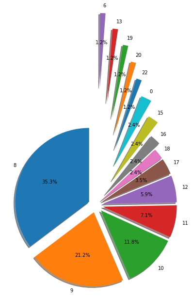

```python
desfase = ( 0.1,0.1, 0.1,0.1, 0.1,0.1, 0.1, 0.2, 0.4, 0.6, 0.8, 1, 1.2, 1.4, 1.6)
grafico = dfa[dfa['region']== 2]['hora'].value_counts()
plt.figure(figsize=(7,7))

plt.pie(grafico, autopct='%1.1f%%', shadow=True, startangle=90, labels = grafico.index, explode=desfase)
```

### Analisis de la muestra en la region de antofagasta

- En la region de antofagasta el horario con una mayor cantidad de requerimientos es a las 08 AM.
- Por lo tanto de la muestra podriamos inferir que entre las 08 AM y 09 AM seria el horario de mayor demanda en la region.
- Entre las 08 AM y 12 PM es el rango horario con mayor frecuencia de requerimientos en esta region.

## Podemos observar que la distribucion horaria de requerimientos en la region de Valparaiso es la siguiente:

```python
groupingpervalpo = dfa[dfa['region']== 5]['contador'].value_counts()
grouping = pd.DataFrame(groupingpervalpo)
grouping = grouping.rename(columns={'contador':'requerimientos'})
grouping
```

|  | requerimientos |
| --- | --- |
| 1 | 139 |

- 139 requerimientos de la muestra son solicitados desde la region de valparaiso.

```python
groupingpervalpo = dfa[dfa['region']== 5]['hora'].value_counts()
grouping = pd.DataFrame(groupingpervalpo)
grouping = grouping.rename(columns={'hora':'requerimientos'})
grouping
```

|  | requerimientos |
| --- | --- |
| 8 | 30 |
| 10 | 23 |
| 9 | 13 |
| 12 | 12 |
| 14 | 10 |
| 7 | 10 |
| 13 | 8 |
| 18 | 7 |
| 11 | 7 |
| 16 | 6 |
| 15 | 6 |
| 19 | 2 |
| 17 | 2 |
| 23 | 1 |
| 20 | 1 |
| 0 | 1 |

- Podemos ver como se distribuye el horario de requerimientos en la region de valparaiso.

```
 [Text(-0.7527227850562054, 0.934563218224016, '8'),
 [Text(-0.4390882912827865, 0.5451618772973426, '21.6%'),
```

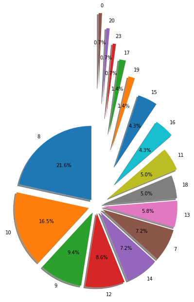

```python
desfase = ( 0.1, 0.1,0.1, 0.1,0.1, 0.1,0.1, 0.1, 0.2, 0.4, 0.6, 0.8, 1, 1.2, 1.4, 1.6)
grafico = dfa[dfa['region']== 5]['hora'].value_counts()
plt.figure(figsize=(7,7))
plt.pie(grafico, autopct='%1.1f%%', shadow=True, startangle=90, labels = grafico.index, explode=desfase)
```

### Analisis de la muestra en la region de valparaiso

- En la region de valparaiso el horario con una mayor cantidad de requerimientos es a las 08 AM.
- Por lo tanto de la muestra podriamos inferir que entre las 08 AM y 10 AM seria el horario de mayor demanda en la region.
- Entre las 07 AM y 13 PM es el rango horario con mayor frecuencia de requerimientos en esta region.

## Podemos observar que la distribucion horaria de requerimientos en la region del maule es la siguiente:

```python
groupingpermaule = dfa[dfa['region']== 7]['contador'].value_counts()
grouping = pd.DataFrame(groupingpermaule)
grouping = grouping.rename(columns={'contador':'requerimientos'})
grouping
```

|  | requerimientos |
| --- | --- |
| 1 | 54 |

- 54 requerimientos de la muestra son solicitados desde la region del maule.

```python
groupingpermaule = dfa[dfa['region']== 7]['hora'].value_counts()
grouping = pd.DataFrame(groupingpermaule)
grouping = grouping.rename(columns={'hora':'requerimientos'})
grouping
```

|  | requerimientos |
| --- | --- |
| 8 | 22 |
| 10 | 6 |
| 9 | 5 |
| 20 | 4 |
| 14 | 3 |
| 13 | 3 |
| 12 | 3 |
| 16 | 2 |
| 6 | 2 |
| 21 | 1 |
| 18 | 1 |
| 17 | 1 |
| 15 | 1 |

- Podemos ver como se distribuye el horario de requerimientos en la region del maule.

## La representacion visual y porcentual de la cantidad de requerimientos agrupados por horario en la region del maule es la siguiente:

```
 [Text(-1.1495874100048165, 0.3441638951988109, '8'),
 [Text(-0.6705926558361428, 0.20076227219930637, '40.7%'),
```

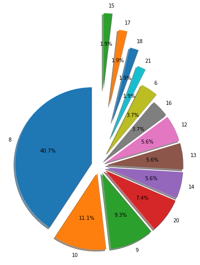

```python
desfase = ( 0.1, 0.1,0.1, 0.1,0.1, 0.1,0.1, 0.1, 0.2, 0.4, 0.6, 0.8, 1)
grafico = dfa[dfa['region']== 7]['hora'].value_counts()
plt.figure(figsize=(7,7))
plt.pie(grafico, autopct='%1.1f%%', shadow=True, startangle=90, labels = grafico.index, explode=desfase)
```

### Analisis de la muestra en la region del maule

- En la region del maule el horario con una mayor cantidad de requerimientos es a las 08 AM. El 40% de los requerimientos de esta region son a las 08 AM.
- Por lo tanto de la muestra podriamos inferir que entre las 08 AM y 10 AM seria el rango horario de mayor demanda en la region.
- Entre las 08 AM y 10 PM y las 12 PM y 14 PM son los rangos horarios con mayor frecuencia de requerimientos en esta region.

## Podemos observar que la distribucion horaria de requerimientos en la region del bio bio es la siguiente:

```python
groupingperbiobio = dfa[dfa['region']== 8]['contador'].value_counts()
grouping = pd.DataFrame(groupingperbiobio)
grouping = grouping.rename(columns={'contador':'requerimientos'})
grouping
```

|  | requerimientos |
| --- | --- |
| 1 | 96 |

- 96 requerimientos de la muestra son solicitados desde la region del bio bio.

```python
groupingperbiobio = dfa[dfa['region']== 8]['hora'].value_counts()
grouping = pd.DataFrame(groupingperbiobio)
grouping = grouping.rename(columns={'hora':'requerimientos'})
grouping
```

|  | requerimientos |
| --- | --- |
| 8 | 28 |
| 10 | 13 |
| 12 | 11 |
| 7 | 10 |
| 9 | 4 |
| 11 | 4 |
| 20 | 3 |
| 17 | 3 |
| 16 | 3 |
| 15 | 3 |
| 21 | 3 |
| 23 | 2 |
| 13 | 2 |
| 14 | 2 |
| 0 | 2 |
| 18 | 1 |
| 3 | 1 |
| 1 | 1 |

- Podemos ver como se distribuye el horario de requerimientos en la region del bio bio.

## La representacion visual y porcentual de la cantidad de requerimientos agrupados por horario en la region del bio bio es la siguiente:

```
 [Text(-0.9520239855509383, 0.7305137445221049, '8'),
 [Text(-0.555347324904714, 0.42613301763789446, '29.2%'),
```

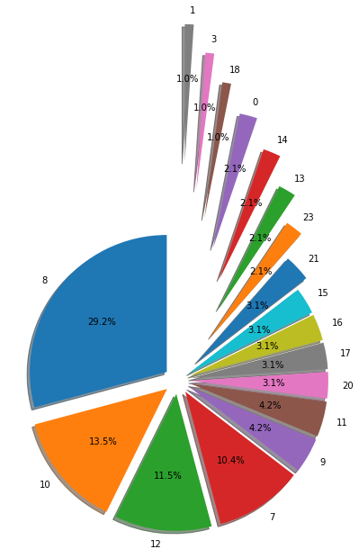

```python
desfase = (0.1, 0.1, 0.1, 0.1,0.1, 0.1,0.1, 0.1,0.1, 0.1, 0.2, 0.4, 0.6, 0.8, 1, 1.2, 1.4, 1.6)
grafico = dfa[dfa['region']== 8]['hora'].value_counts()
plt.figure(figsize=(7,7))
plt.pie(grafico, autopct='%1.1f%%', shadow=True, startangle=90, labels = grafico.index, explode=desfase)
```

### Analisis de la muestra en la region del bio bio

- En la region del bio bio el horario con una mayor cantidad de requerimientos es a las 08 AM.
- Por lo tanto de la muestra podriamos inferir que a las 08 AM y 10 AM serian los horarios de mayor demanda en la region.
- Entre las 07 AM y 12 PM es el rango horario con mayor frecuencia de requerimientos en esta region.

## Conclusion de la distribucion horaria de requerimientos en las regiones seleccionadas:

Las regiones seleccionadas nos describen una baja cantidad de requerimientos en comparacion del total de registros. La unica excepcion seria la region metropolitana, la cual abarca el 52% de los requerimientos de la muestra total seleccionada.

A las 08 AM y 10 AM son las horas de mayor cantidad de requerimientos en la muestra seleccionada.

La tendencia horaria de requerimientos es a las 08 AM. Podriamos inferir que es la hora de mayor demanda.

la frecuencia horaria de requerimientos en las regiones seleccionadas oscila entre el rango de 08 AM a 16 PM.

En ciertas regiones de la muestra seleccionada, existen horarios que no registran requerimientos. Esto debido a la baja frecuencia al momento de agruparlos por horario.

# Descripcion horaria de requerimientos en comunas seleccionadas para el analisis.

## Podemos observar que la distribucion horaria de requerimientos en la comuna de santiago es la siguiente:

```python
groupingpersantiago = dfa[dfa['comuna']== 'Santiago']['contador'].value_counts()
grouping = pd.DataFrame(groupingpersantiago)
grouping = grouping.rename(columns={'contador':'requerimientos'})
grouping
```

|  | requerimientos |
| --- | --- |
| 1 | 124 |

- 124 requerimientos de la muestra son solicitados desde la comuna de santiago.

```python
groupingpersantiago = dfa[dfa['comuna']== 'Santiago']['hora'].value_counts()
grouping = pd.DataFrame(groupingpersantiago)
grouping = grouping.rename(columns={'hora':'requerimientos'})
grouping
```

|  | requerimientos |
| --- | --- |
| 8 | 28 |
| 9 | 14 |
| 12 | 12 |
| 11 | 12 |
| 10 | 11 |
| 7 | 10 |
| 16 | 7 |
| 14 | 6 |
| 13 | 4 |
| 18 | 4 |
| 15 | 4 |
| 20 | 4 |
| 0 | 3 |
| 19 | 2 |
| 17 | 1 |
| 5 | 1 |
| 22 | 1 |

- Podemos ver como se distribuye el horario de requerimientos en la comuna de santiago.

## La representacion visual de la cantidad de requerimientos agrupadas por horario en la comuna de santiago es la siguiente:

```
 [Text(-0.781646960017101, 0.9105097637565589, '8'),
 [Text(-0.45596072667664217, 0.5311306955246593, '22.6%'),
```

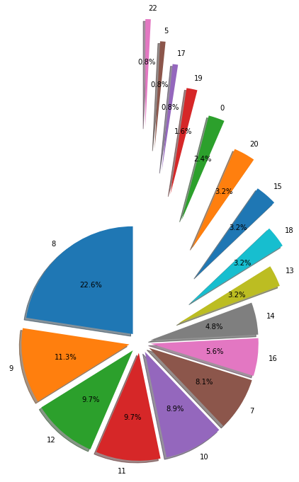

```python
desfase = (0.1,0.1, 0.1,0.1, 0.1,0.1, 0.1,0.1, 0.4, 0.6, 0.8, 1, 1.2, 1.4, 1.6, 1.8, 2)
grafico = dfa[dfa['comuna']== 'Santiago']['hora'].value_counts()
plt.figure(figsize=(7,7))
plt.pie(grafico, autopct='%1.1f%%', shadow=True, startangle=90, labels = grafico.index, explode=desfase)
```

### Analisis de la muestra en la comuna de santiago

- El horario con una mayor cantidad de requerimientos es a las 08 AM en la comuna de santiago.
- Por lo tanto de la muestra podriamos inferir que a las 08 AM y 09 AM serian los horarios de mayor demanda en la comuna.
- Entre las 07 AM y 12 PM es el rango horario con mayor frecuencia de requerimientos en la comuna.

## Podemos observar que la distribucion horaria de requerimientos en la comuna de antofagasta es la siguiente:

```python
groupingperantofagasta = dfa[dfa['comuna']== 'Antofagasta']['contador'].value_counts()
grouping = pd.DataFrame(groupingperantofagasta)
grouping = grouping.rename(columns={'contador':'requerimientos'})
grouping
```

|  | requerimientos |
| --- | --- |
| 1 | 55 |

- 55 requerimientos de la muestra son solicitados desde la comuna de antofagasta.

```python
groupingperantofagasta = dfa[dfa['comuna']== 'Antofagasta']['hora'].value_counts()
grouping = pd.DataFrame(groupingperantofagasta)
grouping = grouping.rename(columns={'hora':'requerimientos'})
grouping
```

|  | requerimientos |
| --- | --- |
| 8 | 19 |
| 9 | 13 |
| 11 | 6 |
| 10 | 6 |
| 12 | 4 |
| 17 | 2 |
| 15 | 1 |
| 6 | 1 |
| 19 | 1 |
| 22 | 1 |
| 0 | 1 |

- Podemos ver como se distribuye el horario de requerimientos en la comuna de antofagasta.

## La representacion visual de la cantidad de requerimientos agrupadas por horario en la comuna de antofagasta es la siguiente:

```
 [Text(-1.0613195143375012, 0.5600007932908763, '8'),
 [Text(-0.619103050030209, 0.32666712941967774, '34.5%'),
```

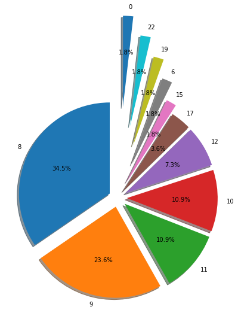

```python
desfase = (0.1,0.1, 0.1,0.1, 0.1,0.1, 0.2, 0.4, 0.6, 0.8, 1)
grafico = dfa[dfa['comuna']== 'Antofagasta']['hora'].value_counts()
plt.figure(figsize=(7,7))
plt.pie(grafico, autopct='%1.1f%%', shadow=True, startangle=90, labels = grafico.index, explode=desfase)
```

### Analisis de la muestra en la comuna de antofagasta

- El horario con una mayor cantidad de requerimientos es a las 08 AM en la comuna de antofagasta.
- Por lo tanto de la muestra se puede apreciar que a las 08 AM y 09 AM serian los horarios de mayor demanda en la comuna.
- Entre las 08 AM y 12 PM es el rango horario con mayor frecuencia de requerimientos en la comuna.

## Podemos observar que la distribucion horaria de requerimientos en la comuna de San Antonio es la siguiente:

```python
groupingpersanantonio = dfa[dfa['comuna']== 'San Antonio']['contador'].value_counts()
grouping = pd.DataFrame(groupingpersanantonio)
grouping = grouping.rename(columns={'contador':'requerimientos'})
grouping
```

|  | requerimientos |
| --- | --- |
| 1 | 33 |

- 33 requerimientos de la muestra son solicitados desde la comuna de san antonio.

```python
groupingpersanantonio = dfa[dfa['comuna']== 'San Antonio']['hora'].value_counts()
grouping = pd.DataFrame(groupingpersanantonio)
grouping = grouping.rename(columns={'hora':'requerimientos'})
grouping
```

|  | requerimientos |
| --- | --- |
| 10 | 6 |
| 12 | 5 |
| 8 | 5 |
| 15 | 3 |
| 9 | 3 |
| 16 | 2 |
| 14 | 2 |
| 7 | 2 |
| 20 | 1 |
| 18 | 1 |
| 17 | 1 |
| 13 | 1 |
| 11 | 1 |

- Podemos ver como se distribuye el horario de requerimientos en la comuna de san antonio.

## La representacion visual de la cantidad de requerimientos agrupadas por horario en la comuna de San Antonio es la siguiente:

```
 [Text(-0.6487689981315546, 1.0095042283533928, '10'),
 [Text(-0.3784485822434069, 0.588877466539479, '18.2%'),
```

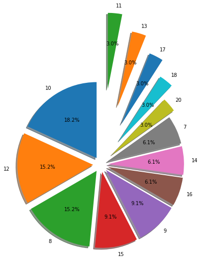

```python
desfase = (0.1, 0.1, 0.1,0.1, 0.1, 0.1, 0.1, 0.1, 0.2, 0.4, 0.6, 0.8, 1)
grafico = dfa[dfa['comuna']== 'San Antonio']['hora'].value_counts()
plt.figure(figsize=(7,7))
plt.pie(grafico, autopct='%1.1f%%', shadow=True, startangle=90, labels = grafico.index, explode=desfase)
```

### Analisis de la muestra en la comuna de San Antonio

- El horario con una mayor cantidad de requerimientos es a las 10 AM en la comuna de San Antonio.
- Por lo tanto de la muestra se puede apreciar que a las 10 AM y 12 PM serian los horarios de mayor demanda en la comuna.
- Entre las 08 AM y 10 AM es el rango horario con mayor frecuencia de requerimientos en la comuna.

## Podemos observar que la distribucion horaria de requerimientos en la comuna de Concepción es la siguiente:

```python
groupingperconcepcion = dfa[dfa['comuna']== 'Concepción']['contador'].value_counts()
grouping = pd.DataFrame(groupingperconcepcion)
grouping = grouping.rename(columns={'contador':'requerimientos'})
grouping
```

|  | requerimientos |
| --- | --- |
| 1 | 27 |

- 27 requerimientos de la muestra son solicitados desde la comuna de concepcion.

```python
groupingperconcepcion = dfa[dfa['comuna']== 'Concepción']['hora'].value_counts()
grouping = pd.DataFrame(groupingperconcepcion)
grouping = grouping.rename(columns={'hora':'requerimientos'})
grouping
```

|  | requerimientos |
| --- | --- |
| 7 | 10 |
| 8 | 4 |
| 10 | 3 |
| 12 | 2 |
| 0 | 2 |
| 14 | 1 |
| 13 | 1 |
| 11 | 1 |
| 20 | 1 |
| 17 | 1 |
| 16 | 1 |

- Podemos ver como se distribuye el horario de requerimientos en la comuna de concepcion.

## La representacion visual de la cantidad de requerimientos agrupadas por horario en la comuna de Concepción es la siguiente:

```
 [Text(-1.1018593101265368, 0.47529576127656836, '7'),
 [Text(-0.6427512642404797, 0.2772558607446648, '37.0%'),
```

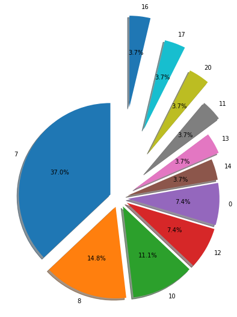

```python
desfase = (0.1,0.1, 0.1,0.1, 0.1,0.1, 0.2, 0.4, 0.6, 0.8, 1)
grafico = dfa[dfa['comuna']== 'Concepción']['hora'].value_counts()
plt.figure(figsize=(7,7))
plt.pie(grafico, autopct='%1.1f%%', shadow=True, startangle=90, labels = grafico.index, explode=desfase)
```

### Analisis de la muestra en la comuna de Concepción

- El horario con una mayor cantidad de requerimientos es a las 07 AM en la comuna de Concepción.
- Por lo tanto de la muestra se puede apreciar que a las 07 AM y 08 AM serian los horarios de mayor demanda en la comuna.
- Entre las 07 AM y 10 PM es el rango horario con mayor frecuencia de requerimientos en la comuna.

## Podemos observar que la distribucion horaria de requerimientos en la comuna de Talca es la siguiente:

```python
groupingpertalca = dfa[dfa['comuna']== 'Talca']['contador'].value_counts()
grouping = pd.DataFrame(groupingpertalca)
grouping = grouping.rename(columns={'contador':'requerimientos'})
grouping
```

|  | requerimientos |
| --- | --- |
| 1 | 10 |

- 10 requerimientos de la muestra son solicitados desde la comuna de Talca.

```python
groupingpertalca = dfa[dfa['comuna']== 'Talca']['hora'].value_counts()
grouping = pd.DataFrame(groupingpertalca)
grouping = grouping.rename(columns={'hora':'requerimientos'})
grouping
```

|  | requerimientos |
| --- | --- |
| 10 | 3 |
| 13 | 1 |
| 12 | 1 |
| 9 | 1 |
| 8 | 1 |
| 20 | 1 |
| 18 | 1 |
| 16 | 1 |

- Podemos ver como se distribuye el horario de requerimientos en la comuna de Talca.

## La representacion visual de la cantidad de requerimientos agrupadas por horario en la comuna de Talca es la siguiente:

```
 [Text(-0.9708204196655013, 0.7053422663930613, '10'),
  Text(1.1999999999999917, 1.4044013496057818e-07, '20'),
 [Text(-0.5663119114715424, 0.41144965539595235, '30.0%'),
  Text(0.6999999999999952, 8.192341206033728e-08, '10.0%'),
```

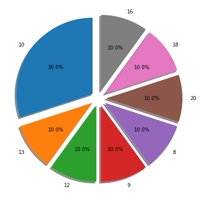

```python
desfase = (0.1,0.1, 0.1,0.1, 0.1, 0.1, 0.1, 0.1)
grafico = dfa[dfa['comuna']== 'Talca']['hora'].value_counts()
plt.figure(figsize=(7,7))
plt.pie(grafico, autopct='%1.1f%%', shadow=True, startangle=90, labels = grafico.index, explode=desfase)
```

## Conclusion de la distribucion horaria de requerimientos en las comunas seleccionadas:

la frecuencia horaria de requerimientos en las comunas seleccionadas oscila entre el rango de 07 AM a 15 PM.

En todas las comunas de la muestra seleccionada, existen horarios que no registran requerimientos. Esto debido a la baja frecuencia al momento de agruparlos por horario.

# Evaluacion

Hallazgos:

- Podemos evaluar que muchos registros extraidos de la muestra seleccionada, fueron un mal ingreso de datos. Valores sin sentido logico y coherente.
- Existen valores de la muestra seleccionada que no representan la realidad de algunas columnas. En unidad de volumen por ejemplo tenemos hora, granel y ninguna.
- No existe una relacion directa entre red de oferta y demanda.
- De la muestra seleccionada, no existen registros de requerimientos en regiones fuera de Chile.
- De la muestra seleccionada la distribucion de requerimientos varia en su mayoria entre lunes a viernes, esto indica que durante la semana existe una mayor cantidad de requerimientos, por lo tanto se deberian evaluar las capacidades tecnicas actuales de los servicios de CamionGO durante la semana para no afectar la distribucion existente.
- Tambien se puede incentivar a que los transportistas se disponibilicen durante la semana en sus regiones correspondientes para poder tener una mayor oferta de disponibilidad para la demanda de requerimientos solicitando transporte.
- El dia lunes es el dia de mayor demanda de requerimientos solicitando transporte de carga, es importante tener en cuenta esta informacion, ya que se puede tomar decisiones respecto a las capacidades tecnicas de camionGO para el dia de mayor demanda en sus servicios.
- De la muestra seleccionada el rango de horario de mayor frecuencia de requerimientos es entre las 8 de la mañana y 12 del dia. Son los horarios donde debe existir una mayor atencion en los servicios de CamionGO.
- De la muestra seleccionada la comuna de Santiago en la comuna con una mayor frecuencia de requerimientos.
- De la muestra seleccionada, las 5 comunas con una mayor frecuencia de demanda de requerimientos son: Santiago, Antofagasta, Lampa, Las Condes, Puerto Montt.
- De la muestra seleccionada, la region con una mayor frecuencia de requerimientos es la region metropolitana.
- El comportamiento de las caracteristicas de los requerimientos a nivel macro resultaron en su gran mayoria no ser un patron o tendencia al momento de analizar las caracteristicas de los requerimientos a un nivel micro.
- De la muestra seleccionada, Cuando se analiza la distribucion de requerimientos a nivel de dia y hora, se presenta un patron solo en la comuna y region con la mayor frecuencia. (Santiago, Region metropolitana). En las 4 comunas y regiones restantes de la muestra para el analisis este patron o tendencia no se repite.
- Se debe mejorar la calidad de los datos. Existen columnas redundantes tales como peso - unidad_peso, volumen - unidad_volumen, ciudad - region y distancia. Se dejaron fuera columnas redundantes tales como tipo_de_camion - tipo_de_camion_otro y tipo_de_carga - tipo_de_carga_otro.
- Existen registros que carecen de un sentido logico y coherente, especialmente en las caracteristicas peso y volumen.
- Cada columa debe poseer datos que representen a esta. A diferencia de los valores atipicos, los datos logicos son aquellos que representan a la columna. Por ejemplo en la columna volumen no puede existir el kilogramo.
- Los datos registrados deben ser acordes al negocio. Existe una norma de carga maxima de transporte de carga terreste en chile. Si bien existen camiones que si pueden transportar mas carga de la permitida, no se deberian permitir registros mayores a la carga maxima permitida.